# Reduced SR in AUD Pilot 2: Behavioral Data Analysis

Author

Milena Musial

Published

June 6, 2024

```r
# Set up

rm(list = ls(all = TRUE))

# Load packages
packages <- c("ggplot2", "dplyr", "tidyr", "kableExtra", "gmodels", "lme4", "sjPlot")
#install.packages(packages)
lapply(packages, library, character.only = TRUE)
```

[output not shown]

```r
# define paths
data_path <- "C:/Users/musialm/OneDrive - Charité - Universitätsmedizin Berlin/PhD/04_B01/WP3/WP3_DATA/PILOT_2/behavioral_data"
demo_path <- "C:/Users/musialm/OneDrive - Charité - Universitätsmedizin Berlin/PhD/04_B01/WP3/WP3_DATA/PILOT_2/demo_data"

# read dfs
load(file.path(data_path, "pilot_data_complete.RData"))
load(file.path(demo_path, "demo_psych_data.RData"))
```

# Learning Phase

## Percent correct overall

- ~20% higher compared to pilot 1

```r
learning_correct_df <- trial_df %>%
  filter(phase == "learning",
         state %in% c(1,2,3)
         ) %>%
  group_by(phase) %>%
  summarise(mean_correct = mean(correct, na.rm = TRUE),
            se_correct = sd(correct, na.rm = TRUE)/sqrt(n()),
            ci_l = ci(correct, na.rm=TRUE)[2],
            ci_u = ci(correct, na.rm=TRUE)[3],
            n = n()
            )

learning_correct_df %>%
  kable("html") %>%
  kable_styling(font_size = 24,
                latex_options = "scale_down")
```

| phase | mean_correct | se_correct | ci_l | ci_u | n |
| --- | --- | --- | --- | --- | --- |
| learning | 0.9318333 | 0.003254 | 0.9254544 | 0.9382123 | 6000 |

## Percent correct per component (and state)

- no differences in % correct decisions from states 1, 2, 3 between conditions

```r
learning_correct_component_state_df <- trial_df %>%
  filter(phase == "learning",
         state %in% c(1,2,3)
         ) %>%
  group_by(component, state) %>%
  summarise(mean_correct = mean(correct, na.rm = TRUE),
            se_correct = sd(correct, na.rm = TRUE)/sqrt(n()),
            ci_l = ci(correct, na.rm=TRUE)[2],
            ci_u = ci(correct, na.rm=TRUE)[3],
            n = n()
            ) %>%
  mutate(state=as.factor(state))

learning_correct_component_state_df %>%
  kable("html") %>%
  kable_styling(font_size = 18,
                latex_options = "scale_down")
```

| component | state | mean_correct | se_correct | ci_l | ci_u | n |
| --- | --- | --- | --- | --- | --- | --- |
| control-learning | 1 | 0.9166667 | 0.0112928 | 0.8944884 | 0.9388450 | 600 |
| control-learning | 2 | 0.9370370 | 0.0148097 | 0.9078795 | 0.9661946 | 270 |
| control-learning | 3 | 0.9393939 | 0.0131548 | 0.9135158 | 0.9652721 | 330 |
| goal-state-learning | 1 | 0.9066667 | 0.0118858 | 0.8833237 | 0.9300096 | 600 |
| goal-state-learning | 2 | 0.9548872 | 0.0127498 | 0.9297834 | 0.9799910 | 266 |
| goal-state-learning | 3 | 0.9550898 | 0.0113494 | 0.9327643 | 0.9774154 | 334 |
| policy-learning | 1 | 0.9450000 | 0.0093150 | 0.9267059 | 0.9632941 | 600 |
| policy-learning | 2 | 0.9298246 | 0.0195915 | 0.8911505 | 0.9684986 | 171 |
| policy-learning | 3 | 0.9463869 | 0.0108880 | 0.9249864 | 0.9677875 | 429 |
| reward-learning | 1 | 0.9183333 | 0.0111895 | 0.8963580 | 0.9403087 | 600 |
| reward-learning | 2 | 0.9490196 | 0.0138014 | 0.9218399 | 0.9761993 | 255 |
| reward-learning | 3 | 0.9362319 | 0.0131739 | 0.9103204 | 0.9621434 | 345 |
| transition-learning | 1 | 0.9233333 | 0.0108710 | 0.9019834 | 0.9446832 | 600 |
| transition-learning | 2 | 0.9274809 | 0.0160531 | 0.8958709 | 0.9590910 | 262 |
| transition-learning | 3 | 0.9349112 | 0.0134376 | 0.9084790 | 0.9613435 | 338 |

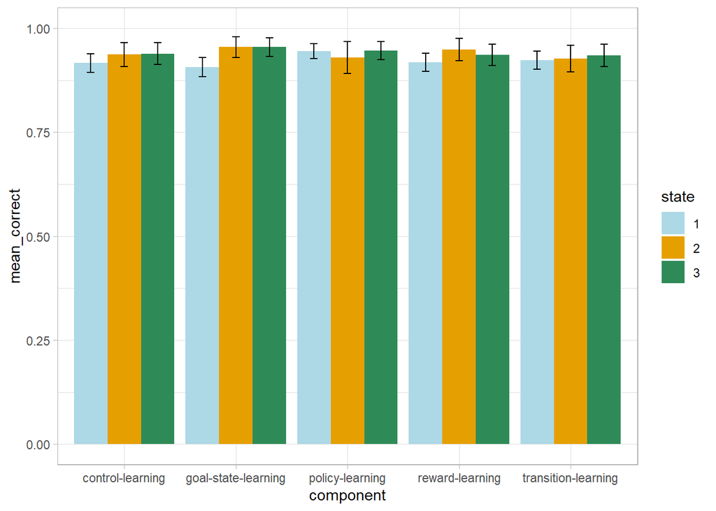

```r
# bar plot
ggplot(learning_correct_component_state_df, aes(x=component, y=mean_correct, fill=state)) +
  geom_bar(stat="identity", position=position_dodge()) +
  geom_errorbar(aes(ymin=ci_l, ymax=ci_u), width=.2,
                position=position_dodge(.9)) +
  theme_light() +
  scale_y_continuous(limits = c(0, 1)) +
  theme_light() +
  scale_fill_manual(values=c('lightblue','#E69F00','seagreen'))
```

### LogReg: Difference from control condition

```r
logreg_learning_correct_condition_df <- trial_df %>%
  filter(phase == "learning") %>%
  mutate(correct = as.factor(correct),
         condition = as.factor(condition)) %>%
  select(ID,
         correct,
         condition)

contrasts(logreg_learning_correct_condition_df$condition) <- contr.treatment(5, base = 1)

log_model_learning_control <- glmer(correct ~ condition + (1 | ID), data = logreg_learning_correct_condition_df, family = "binomial")

tab_model(log_model_learning_control, transform = NULL, show.est = T, show.stat = T, auto.label = FALSE, CSS = list(css.table = '+font-size: 14;'))
```

|  | correct |  |  |  |
| --- | --- | --- | --- | --- |
| Predictors | Log-Odds | CI | Statistic | p |
| (Intercept) | 3.54 | 3.00 – 4.09 | 12.75 | **<0.001** |
| condition2 | 0.06 | -0.27 – 0.39 | 0.35 | 0.724 |
| condition3 | 0.31 | -0.04 – 0.66 | 1.74 | 0.082 |
| condition4 | 0.04 | -0.29 – 0.38 | 0.26 | 0.791 |
| condition5 | -0.00 | -0.33 – 0.33 | -0.00 | 1.000 |
| Random Effects |  |  |  |  |
| σ<sup>2</sup> | 3.29 |  |  |  |
| τ<sub>00</sub> <sub>ID</sub> | 2.68 |  |  |  |
| ICC | 0.45 |  |  |  |
| N <sub>ID</sub> | 50 |  |  |  |
| Observations | 6000 |  |  |  |
| Marginal R<sup>2</sup> / Conditional R<sup>2</sup> | 0.002 / 0.450 |  |  |  |

### LogReg: Difference from goal-state condition

```r
contrasts(logreg_learning_correct_condition_df$condition) <- contr.treatment(5, base = 2)

log_model_learning_goalstate <- glmer(correct ~ condition + (1 | ID), data = logreg_learning_correct_condition_df, family = "binomial")
tab_model(log_model_learning_goalstate, transform = NULL, show.est = T, show.stat = T, auto.label = FALSE, CSS = list(css.table = '+font-size: 14;'))
```

|  | correct |  |  |  |
| --- | --- | --- | --- | --- |
| Predictors | Log-Odds | CI | Statistic | p |
| (Intercept) | 3.60 | 3.05 – 4.15 | 12.91 | **<0.001** |
| condition1 | -0.06 | -0.39 – 0.27 | -0.35 | 0.723 |
| condition3 | 0.25 | -0.10 – 0.60 | 1.39 | 0.165 |
| condition4 | -0.02 | -0.35 – 0.32 | -0.09 | 0.929 |
| condition5 | -0.06 | -0.39 – 0.27 | -0.35 | 0.723 |
| Random Effects |  |  |  |  |
| σ<sup>2</sup> | 3.29 |  |  |  |
| τ<sub>00</sub> <sub>ID</sub> | 2.68 |  |  |  |
| ICC | 0.45 |  |  |  |
| N <sub>ID</sub> | 50 |  |  |  |
| Observations | 6000 |  |  |  |
| Marginal R<sup>2</sup> / Conditional R<sup>2</sup> | 0.002 / 0.450 |  |  |  |

### LogReg: Difference from policy condition

```r
contrasts(logreg_learning_correct_condition_df$condition) <- contr.treatment(5, base = 3)

log_model_learning_reward <- glmer(correct ~ condition + (1 | ID), data = logreg_learning_correct_condition_df, family = "binomial")
tab_model(log_model_learning_reward, transform = NULL, show.est = T, show.stat = T, auto.label = FALSE, CSS = list(css.table = '+font-size: 14;'))
```

|  | correct |  |  |  |
| --- | --- | --- | --- | --- |
| Predictors | Log-Odds | CI | Statistic | p |
| (Intercept) | 3.85 | 3.29 – 4.41 | 13.54 | **<0.001** |
| condition1 | -0.31 | -0.66 – 0.04 | -1.74 | 0.082 |
| condition2 | -0.25 | -0.60 – 0.10 | -1.39 | 0.165 |
| condition4 | -0.26 | -0.61 – 0.09 | -1.48 | 0.140 |
| condition5 | -0.31 | -0.66 – 0.04 | -1.74 | 0.082 |
| Random Effects |  |  |  |  |
| σ<sup>2</sup> | 3.29 |  |  |  |
| τ<sub>00</sub> <sub>ID</sub> | 2.68 |  |  |  |
| ICC | 0.45 |  |  |  |
| N <sub>ID</sub> | 50 |  |  |  |
| Observations | 6000 |  |  |  |
| Marginal R<sup>2</sup> / Conditional R<sup>2</sup> | 0.002 / 0.450 |  |  |  |

### LogReg: Difference from reward condition

```r
contrasts(logreg_learning_correct_condition_df$condition) <- contr.treatment(5, base = 4)

log_model_learning_transition <- glmer(correct ~ condition + (1 | ID), data = logreg_learning_correct_condition_df, family = "binomial")
tab_model(log_model_learning_transition, transform = NULL, show.est = T, show.stat = T, auto.label = FALSE, CSS = list(css.table = '+font-size: 14;'))
```

|  | correct |  |  |  |
| --- | --- | --- | --- | --- |
| Predictors | Log-Odds | CI | Statistic | p |
| (Intercept) | 3.59 | 3.04 – 4.13 | 12.86 | **<0.001** |
| condition1 | -0.04 | -0.38 – 0.29 | -0.26 | 0.791 |
| condition2 | 0.02 | -0.32 – 0.35 | 0.09 | 0.929 |
| condition3 | 0.26 | -0.09 – 0.61 | 1.48 | 0.140 |
| condition5 | -0.04 | -0.38 – 0.29 | -0.26 | 0.791 |
| Random Effects |  |  |  |  |
| σ<sup>2</sup> | 3.29 |  |  |  |
| τ<sub>00</sub> <sub>ID</sub> | 2.68 |  |  |  |
| ICC | 0.45 |  |  |  |
| N <sub>ID</sub> | 50 |  |  |  |
| Observations | 6000 |  |  |  |
| Marginal R<sup>2</sup> / Conditional R<sup>2</sup> | 0.002 / 0.450 |  |  |  |

### LogReg: Difference from transition condition

```r
contrasts(logreg_learning_correct_condition_df$condition) <- contr.treatment(5, base = 5)

log_model_learning_transition <- glmer(correct ~ condition + (1 | ID), data = logreg_learning_correct_condition_df, family = "binomial")
tab_model(log_model_learning_transition, transform = NULL, show.est = T, show.stat = T, auto.label = FALSE, CSS = list(css.table = '+font-size: 14;'))
```

|  | correct |  |  |  |
| --- | --- | --- | --- | --- |
| Predictors | Log-Odds | CI | Statistic | p |
| (Intercept) | 3.54 | 3.00 – 4.09 | 12.74 | **<0.001** |
| condition1 | -0.00 | -0.33 – 0.33 | -0.00 | 1.000 |
| condition2 | 0.06 | -0.27 – 0.39 | 0.35 | 0.723 |
| condition3 | 0.31 | -0.04 – 0.66 | 1.74 | 0.082 |
| condition4 | 0.04 | -0.29 – 0.38 | 0.26 | 0.791 |
| Random Effects |  |  |  |  |
| σ<sup>2</sup> | 3.29 |  |  |  |
| τ<sub>00</sub> <sub>ID</sub> | 2.68 |  |  |  |
| ICC | 0.45 |  |  |  |
| N <sub>ID</sub> | 50 |  |  |  |
| Observations | 6000 |  |  |  |
| Marginal R<sup>2</sup> / Conditional R<sup>2</sup> | 0.002 / 0.450 |  |  |  |

## Percent correct paths per component

- no differences in % correct paths (correct state 1 and state 2/3 choice) between conditions

```r
learning_correct_path_component_df <- trial_df %>%
  filter(phase == "learning",
         state %in% c(1)
         ) %>%
  group_by(component) %>%
  summarise(mean_correct = mean(correct_path, na.rm = TRUE),
            se_correct = sd(correct_path, na.rm = TRUE)/sqrt(n()),
            ci_l = ci(correct_path, na.rm=TRUE)[2],
            ci_u = ci(correct_path, na.rm=TRUE)[3],
            n = n()
            )

learning_correct_path_component_df %>%
  kable("html") %>%
  kable_styling(font_size = 18,
                latex_options = "scale_down")
```

| component | mean_correct | se_correct | ci_l | ci_u | n |
| --- | --- | --- | --- | --- | --- |
| control-learning | 0.8833333 | 0.0131166 | 0.8575732 | 0.9090935 | 600 |
| goal-state-learning | 0.8800000 | 0.0132776 | 0.8539238 | 0.9060762 | 600 |
| policy-learning | 0.9066667 | 0.0118858 | 0.8833237 | 0.9300096 | 600 |
| reward-learning | 0.8850000 | 0.0130349 | 0.8594004 | 0.9105996 | 600 |
| transition-learning | 0.8866667 | 0.0129523 | 0.8612293 | 0.9121040 | 600 |

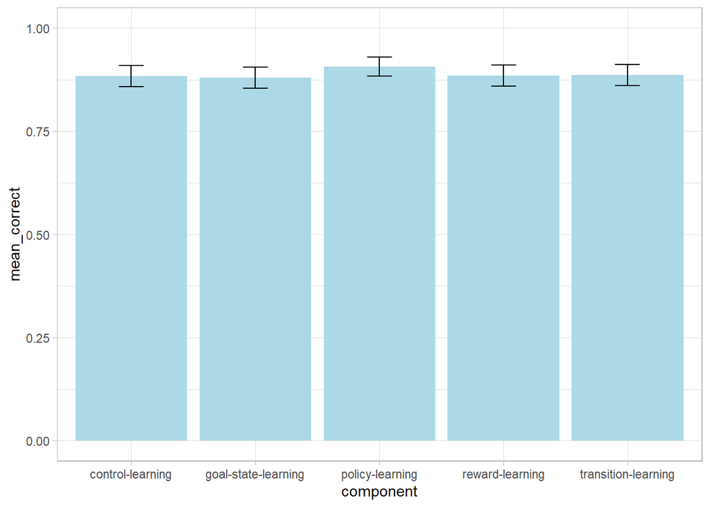

```r
# bar plot
ggplot(learning_correct_path_component_df, aes(x=component, y=mean_correct)) +
  geom_bar(stat="identity", fill="lightblue") +
  geom_errorbar(aes(ymin=ci_l, ymax=ci_u), width=.2,
                position=position_dodge(.9)) +
  theme_light() +
  scale_y_continuous(limits = c(0, 1)) +
  theme_light()
```

## Time effects

### Percent correct all states per component over time

```r
# get percent correct over time
learning_correct_component_time_df <- trial_df %>%
  filter(phase == "learning",
         state %in% c(1,2,3)
         ) %>%
  mutate(time_bin = cut(
    trial,
    breaks = 4,
    labels = c("T1", "T2", "T3", "T4")
    )
  ) %>%
  group_by(component, time_bin) %>%
  summarise(mean_correct = mean(correct, na.rm = TRUE),
            se_correct = sd(correct, na.rm = TRUE)/sqrt(n()),
            ci_l = ci(correct, na.rm=TRUE)[2],
            ci_u = ci(correct, na.rm=TRUE)[3],
            n = n()
            )

learning_correct_component_time_df %>%
  kable("html") %>%
  kable_styling(font_size = 14,
                latex_options = "scale_down")
```

| component | time_bin | mean_correct | se_correct | ci_l | ci_u | n |
| --- | --- | --- | --- | --- | --- | --- |
| control-learning | T1 | 0.8733333 | 0.0192347 | 0.8354808 | 0.9111859 | 300 |
| control-learning | T2 | 0.9333333 | 0.0144257 | 0.9049446 | 0.9617221 | 300 |
| control-learning | T3 | 0.9533333 | 0.0121980 | 0.9293284 | 0.9773382 | 300 |
| control-learning | T4 | 0.9500000 | 0.0126041 | 0.9251961 | 0.9748039 | 300 |
| goal-state-learning | T1 | 0.8933333 | 0.0178519 | 0.8582020 | 0.9284647 | 300 |
| goal-state-learning | T2 | 0.9433333 | 0.0133709 | 0.9170203 | 0.9696463 | 300 |
| goal-state-learning | T3 | 0.9466667 | 0.0129946 | 0.9210942 | 0.9722391 | 300 |
| goal-state-learning | T4 | 0.9400000 | 0.0137342 | 0.9129720 | 0.9670280 | 300 |
| policy-learning | T1 | 0.9233333 | 0.0153868 | 0.8930533 | 0.9536134 | 300 |
| policy-learning | T2 | 0.9466667 | 0.0129946 | 0.9210942 | 0.9722391 | 300 |
| policy-learning | T3 | 0.9633333 | 0.0108690 | 0.9419440 | 0.9847227 | 300 |
| policy-learning | T4 | 0.9400000 | 0.0137342 | 0.9129720 | 0.9670280 | 300 |
| reward-learning | T1 | 0.8933333 | 0.0178519 | 0.8582020 | 0.9284647 | 300 |
| reward-learning | T2 | 0.9200000 | 0.0156893 | 0.8891246 | 0.9508754 | 300 |
| reward-learning | T3 | 0.9466667 | 0.0129946 | 0.9210942 | 0.9722391 | 300 |
| reward-learning | T4 | 0.9600000 | 0.0113326 | 0.9376982 | 0.9823018 | 300 |
| transition-learning | T1 | 0.9066667 | 0.0168231 | 0.8735599 | 0.9397734 | 300 |
| transition-learning | T2 | 0.9233333 | 0.0153868 | 0.8930533 | 0.9536134 | 300 |
| transition-learning | T3 | 0.9300000 | 0.0147555 | 0.9009621 | 0.9590379 | 300 |
| transition-learning | T4 | 0.9500000 | 0.0126041 | 0.9251961 | 0.9748039 | 300 |

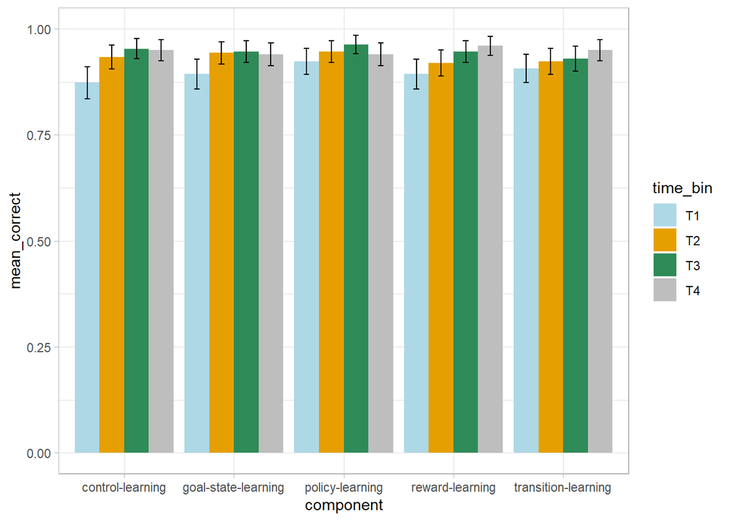

```r
ggplot(learning_correct_component_time_df, aes(x=component, y=mean_correct, fill=time_bin)) +
  geom_bar(stat="identity", position=position_dodge()) +
  geom_errorbar(aes(ymin=ci_l, ymax=ci_u), width=.2,
                position=position_dodge(.9)) +
  scale_y_continuous(limits = c(0, 1)) +
  theme_light() +
  scale_fill_manual(values=c('lightblue','#E69F00','seagreen','grey'))
```

### Percent correct state 1 over time

- slight increase from earlier to later trials
- already starts off >75%

```r
# get percent correct over time
learning_state1_correct_component_time_df <- trial_df %>%
  filter(phase == "learning",
         state %in% c(1)
         ) %>%
  group_by(ID, condition) %>%
  mutate(accumulated_state1_visits = row_number()
         ) %>%
  group_by(condition, accumulated_state1_visits) %>%
  summarise(mean_correct_state_1 = mean(correct_state_1, na.rm = TRUE),
            se_correct_state_1 = sd(correct_state_1, na.rm = TRUE)/sqrt(n()),
            ci_l = ci(correct_state_1, na.rm=TRUE)[2],
            ci_u = ci(correct_state_1, na.rm=TRUE)[3],
            n = n()
            )

learning_state1_correct_component_time_df %>%
  kable("html") %>%
  kable_styling(font_size = 14,
                latex_options = "scale_down")
```

| condition | accumulated_state1_visits | mean_correct_state_1 | se_correct_state_1 | ci_l | ci_u | n |
| --- | --- | --- | --- | --- | --- | --- |
| control | 1 | 0.84 | 0.0523723 | 0.7347539 | 0.9452461 | 50 |
| control | 2 | 0.80 | 0.0571429 | 0.6851671 | 0.9148329 | 50 |
| control | 3 | 0.88 | 0.0464231 | 0.7867093 | 0.9732907 | 50 |
| control | 4 | 0.94 | 0.0339267 | 0.8718218 | 1.0081782 | 50 |
| control | 5 | 0.94 | 0.0339267 | 0.8718218 | 1.0081782 | 50 |
| control | 6 | 0.88 | 0.0464231 | 0.7867093 | 0.9732907 | 50 |
| control | 7 | 0.94 | 0.0339267 | 0.8718218 | 1.0081782 | 50 |
| control | 8 | 0.94 | 0.0339267 | 0.8718218 | 1.0081782 | 50 |
| control | 9 | 1.00 | 0.0000000 | 1.0000000 | 1.0000000 | 50 |
| control | 10 | 0.98 | 0.0200000 | 0.9398085 | 1.0201915 | 50 |
| control | 11 | 0.96 | 0.0279942 | 0.9037436 | 1.0162564 | 50 |
| control | 12 | 0.90 | 0.0428571 | 0.8138753 | 0.9861247 | 50 |
| goal-state | 1 | 0.86 | 0.0495696 | 0.7603862 | 0.9596138 | 50 |
| goal-state | 2 | 0.80 | 0.0571429 | 0.6851671 | 0.9148329 | 50 |
| goal-state | 3 | 0.88 | 0.0464231 | 0.7867093 | 0.9732907 | 50 |
| goal-state | 4 | 0.94 | 0.0339267 | 0.8718218 | 1.0081782 | 50 |
| goal-state | 5 | 0.94 | 0.0339267 | 0.8718218 | 1.0081782 | 50 |
| goal-state | 6 | 0.94 | 0.0339267 | 0.8718218 | 1.0081782 | 50 |
| goal-state | 7 | 0.90 | 0.0428571 | 0.8138753 | 0.9861247 | 50 |
| goal-state | 8 | 0.92 | 0.0387562 | 0.8421166 | 0.9978834 | 50 |
| goal-state | 9 | 0.96 | 0.0279942 | 0.9037436 | 1.0162564 | 50 |
| goal-state | 10 | 0.90 | 0.0428571 | 0.8138753 | 0.9861247 | 50 |
| goal-state | 11 | 0.96 | 0.0279942 | 0.9037436 | 1.0162564 | 50 |
| goal-state | 12 | 0.88 | 0.0464231 | 0.7867093 | 0.9732907 | 50 |
| policy | 1 | 0.92 | 0.0387562 | 0.8421166 | 0.9978834 | 50 |
| policy | 2 | 0.96 | 0.0279942 | 0.9037436 | 1.0162564 | 50 |
| policy | 3 | 0.90 | 0.0428571 | 0.8138753 | 0.9861247 | 50 |
| policy | 4 | 0.92 | 0.0387562 | 0.8421166 | 0.9978834 | 50 |
| policy | 5 | 0.96 | 0.0279942 | 0.9037436 | 1.0162564 | 50 |
| policy | 6 | 0.96 | 0.0279942 | 0.9037436 | 1.0162564 | 50 |
| policy | 7 | 0.96 | 0.0279942 | 0.9037436 | 1.0162564 | 50 |
| policy | 8 | 0.96 | 0.0279942 | 0.9037436 | 1.0162564 | 50 |
| policy | 9 | 0.96 | 0.0279942 | 0.9037436 | 1.0162564 | 50 |
| policy | 10 | 0.90 | 0.0428571 | 0.8138753 | 0.9861247 | 50 |
| policy | 11 | 0.96 | 0.0279942 | 0.9037436 | 1.0162564 | 50 |
| policy | 12 | 0.98 | 0.0200000 | 0.9398085 | 1.0201915 | 50 |
| reward | 1 | 0.76 | 0.0610119 | 0.6373920 | 0.8826080 | 50 |
| reward | 2 | 0.96 | 0.0279942 | 0.9037436 | 1.0162564 | 50 |
| reward | 3 | 0.88 | 0.0464231 | 0.7867093 | 0.9732907 | 50 |
| reward | 4 | 0.90 | 0.0428571 | 0.8138753 | 0.9861247 | 50 |
| reward | 5 | 0.92 | 0.0387562 | 0.8421166 | 0.9978834 | 50 |
| reward | 6 | 0.96 | 0.0279942 | 0.9037436 | 1.0162564 | 50 |
| reward | 7 | 0.90 | 0.0428571 | 0.8138753 | 0.9861247 | 50 |
| reward | 8 | 0.92 | 0.0387562 | 0.8421166 | 0.9978834 | 50 |
| reward | 9 | 0.98 | 0.0200000 | 0.9398085 | 1.0201915 | 50 |
| reward | 10 | 0.94 | 0.0339267 | 0.8718218 | 1.0081782 | 50 |
| reward | 11 | 0.94 | 0.0339267 | 0.8718218 | 1.0081782 | 50 |
| reward | 12 | 0.96 | 0.0279942 | 0.9037436 | 1.0162564 | 50 |
| transition | 1 | 0.92 | 0.0387562 | 0.8421166 | 0.9978834 | 50 |
| transition | 2 | 0.88 | 0.0464231 | 0.7867093 | 0.9732907 | 50 |
| transition | 3 | 0.92 | 0.0387562 | 0.8421166 | 0.9978834 | 50 |
| transition | 4 | 0.96 | 0.0279942 | 0.9037436 | 1.0162564 | 50 |
| transition | 5 | 0.92 | 0.0387562 | 0.8421166 | 0.9978834 | 50 |
| transition | 6 | 0.92 | 0.0387562 | 0.8421166 | 0.9978834 | 50 |
| transition | 7 | 0.92 | 0.0387562 | 0.8421166 | 0.9978834 | 50 |
| transition | 8 | 0.86 | 0.0495696 | 0.7603862 | 0.9596138 | 50 |
| transition | 9 | 0.96 | 0.0279942 | 0.9037436 | 1.0162564 | 50 |
| transition | 10 | 0.96 | 0.0279942 | 0.9037436 | 1.0162564 | 50 |
| transition | 11 | 0.96 | 0.0279942 | 0.9037436 | 1.0162564 | 50 |
| transition | 12 | 0.90 | 0.0428571 | 0.8138753 | 0.9861247 | 50 |

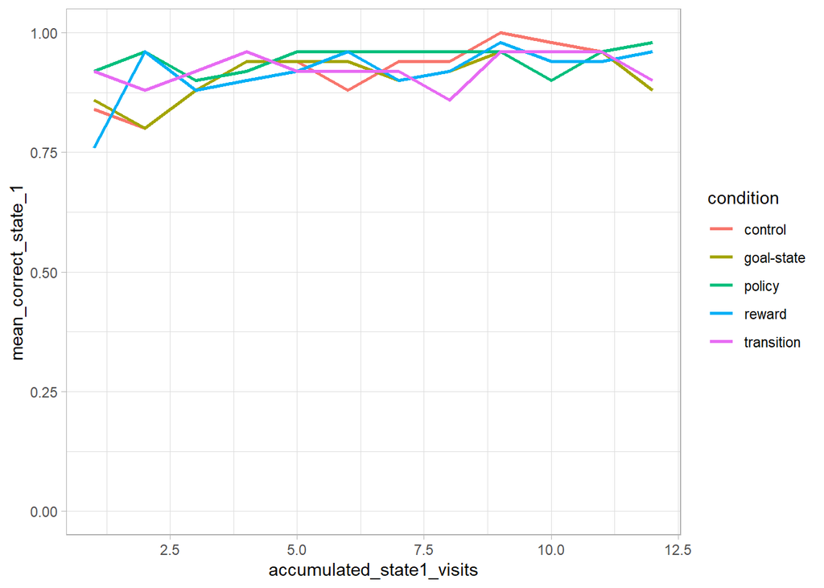

```r
# bar plot state 1
ggplot(learning_state1_correct_component_time_df, aes(x=accumulated_state1_visits, y=mean_correct_state_1, fill=condition)) +
  geom_line(aes(color=condition), size=1) +
  scale_y_continuous(limits = c(0, 1)) +
  theme_light() +
  scale_fill_manual(values=c('lightblue','#E69F00','seagreen','grey','pink'))
```

### Percent correct state 2 over time

- ceiling effect after ~ half of trials

```r
# get percent correct over time
learning_state2_correct_component_time_df <- trial_df %>%
  filter(phase == "learning",
         state %in% c(2)
         ) %>%
  group_by(ID, condition) %>%
  mutate(accumulated_state2_visits = row_number()
         ) %>%
  group_by(condition, accumulated_state2_visits) %>%
  summarise(mean_correct_state_2 = mean(correct_state_2, na.rm = TRUE),
            se_correct_state_2 = sd(correct_state_2, na.rm = TRUE)/sqrt(n()),
            ci_l = ci(correct_state_2, na.rm=TRUE)[2],
            ci_u = ci(correct_state_2, na.rm=TRUE)[3],
            n = n()
            )

learning_state2_correct_component_time_df %>%
  kable("html") %>%
  kable_styling(font_size = 14,
                latex_options = "scale_down")
```

| condition | accumulated_state2_visits | mean_correct_state_2 | se_correct_state_2 | ci_l | ci_u | n |
| --- | --- | --- | --- | --- | --- | --- |
| control | 1 | 0.9090909 | 0.0508197 | 0.8055745 | 1.0126073 | 33 |
| control | 2 | 0.8333333 | 0.0692046 | 0.6917941 | 0.9748726 | 30 |
| control | 3 | 0.8518519 | 0.0696696 | 0.7086439 | 0.9950598 | 27 |
| control | 4 | 0.8750000 | 0.0689597 | 0.7323461 | 1.0176539 | 24 |
| control | 5 | 1.0000000 | 0.0000000 | 1.0000000 | 1.0000000 | 23 |
| control | 6 | 1.0000000 | 0.0000000 | 1.0000000 | 1.0000000 | 22 |
| control | 7 | 1.0000000 | 0.0000000 | 1.0000000 | 1.0000000 | 21 |
| control | 8 | 1.0000000 | 0.0000000 | 1.0000000 | 1.0000000 | 21 |
| control | 9 | 0.9500000 | 0.0500000 | 0.8453488 | 1.0546512 | 20 |
| control | 10 | 1.0000000 | 0.0000000 | 1.0000000 | 1.0000000 | 19 |
| control | 11 | 1.0000000 | 0.0000000 | 1.0000000 | 1.0000000 | 18 |
| control | 12 | 0.9166667 | 0.0833333 | 0.7332512 | 1.1000821 | 12 |
| goal-state | 1 | 0.8750000 | 0.0593989 | 0.7538552 | 0.9961448 | 32 |
| goal-state | 2 | 0.8620690 | 0.0651663 | 0.7285819 | 0.9955561 | 29 |
| goal-state | 3 | 0.9600000 | 0.0400000 | 0.8774441 | 1.0425559 | 25 |
| goal-state | 4 | 0.9565217 | 0.0434783 | 0.8663533 | 1.0466901 | 23 |
| goal-state | 5 | 1.0000000 | 0.0000000 | 1.0000000 | 1.0000000 | 23 |
| goal-state | 6 | 0.9130435 | 0.0600739 | 0.7884579 | 1.0376290 | 23 |
| goal-state | 7 | 1.0000000 | 0.0000000 | 1.0000000 | 1.0000000 | 21 |
| goal-state | 8 | 1.0000000 | 0.0000000 | 1.0000000 | 1.0000000 | 20 |
| goal-state | 9 | 1.0000000 | 0.0000000 | 1.0000000 | 1.0000000 | 19 |
| goal-state | 10 | 1.0000000 | 0.0000000 | 1.0000000 | 1.0000000 | 19 |
| goal-state | 11 | 1.0000000 | 0.0000000 | 1.0000000 | 1.0000000 | 19 |
| goal-state | 12 | 1.0000000 | 0.0000000 | 1.0000000 | 1.0000000 | 13 |
| policy | 1 | 0.9047619 | 0.0656383 | 0.7678428 | 1.0416811 | 21 |
| policy | 2 | 0.7368421 | 0.1037909 | 0.5187856 | 0.9548986 | 19 |
| policy | 3 | 0.8888889 | 0.0762216 | 0.7280754 | 1.0497024 | 18 |
| policy | 4 | 0.9333333 | 0.0666667 | 0.7903476 | 1.0763191 | 15 |
| policy | 5 | 0.9333333 | 0.0666667 | 0.7903476 | 1.0763191 | 15 |
| policy | 6 | 0.9285714 | 0.0714286 | 0.7742594 | 1.0828835 | 14 |
| policy | 7 | 1.0000000 | 0.0000000 | 1.0000000 | 1.0000000 | 13 |
| policy | 8 | 1.0000000 | 0.0000000 | 1.0000000 | 1.0000000 | 12 |
| policy | 9 | 1.0000000 | 0.0000000 | 1.0000000 | 1.0000000 | 12 |
| policy | 10 | 1.0000000 | 0.0000000 | 1.0000000 | 1.0000000 | 12 |
| policy | 11 | 1.0000000 | 0.0000000 | 1.0000000 | 1.0000000 | 11 |
| policy | 12 | 1.0000000 | 0.0000000 | 1.0000000 | 1.0000000 | 9 |
| reward | 1 | 0.8787879 | 0.0576953 | 0.7612665 | 0.9963093 | 33 |
| reward | 2 | 0.8846154 | 0.0638971 | 0.7530168 | 1.0162139 | 26 |
| reward | 3 | 0.9166667 | 0.0576303 | 0.7974492 | 1.0358841 | 24 |
| reward | 4 | 0.9166667 | 0.0576303 | 0.7974492 | 1.0358841 | 24 |
| reward | 5 | 0.9130435 | 0.0600739 | 0.7884579 | 1.0376290 | 23 |
| reward | 6 | 1.0000000 | 0.0000000 | 1.0000000 | 1.0000000 | 22 |
| reward | 7 | 1.0000000 | 0.0000000 | 1.0000000 | 1.0000000 | 19 |
| reward | 8 | 1.0000000 | 0.0000000 | 1.0000000 | 1.0000000 | 19 |
| reward | 9 | 1.0000000 | 0.0000000 | 1.0000000 | 1.0000000 | 18 |
| reward | 10 | 1.0000000 | 0.0000000 | 1.0000000 | 1.0000000 | 18 |
| reward | 11 | 1.0000000 | 0.0000000 | 1.0000000 | 1.0000000 | 16 |
| reward | 12 | 1.0000000 | 0.0000000 | 1.0000000 | 1.0000000 | 13 |
| transition | 1 | 0.8666667 | 0.0631243 | 0.7375630 | 0.9957703 | 30 |
| transition | 2 | 0.8000000 | 0.0816497 | 0.6314834 | 0.9685166 | 25 |
| transition | 3 | 0.8400000 | 0.0748331 | 0.6855520 | 0.9944480 | 25 |
| transition | 4 | 0.9600000 | 0.0400000 | 0.8774441 | 1.0425559 | 25 |
| transition | 5 | 0.8800000 | 0.0663325 | 0.7430965 | 1.0169035 | 25 |
| transition | 6 | 0.9166667 | 0.0576303 | 0.7974492 | 1.0358841 | 24 |
| transition | 7 | 1.0000000 | 0.0000000 | 1.0000000 | 1.0000000 | 20 |
| transition | 8 | 1.0000000 | 0.0000000 | 1.0000000 | 1.0000000 | 19 |
| transition | 9 | 1.0000000 | 0.0000000 | 1.0000000 | 1.0000000 | 18 |
| transition | 10 | 1.0000000 | 0.0000000 | 1.0000000 | 1.0000000 | 18 |
| transition | 11 | 1.0000000 | 0.0000000 | 1.0000000 | 1.0000000 | 18 |
| transition | 12 | 1.0000000 | 0.0000000 | 1.0000000 | 1.0000000 | 15 |

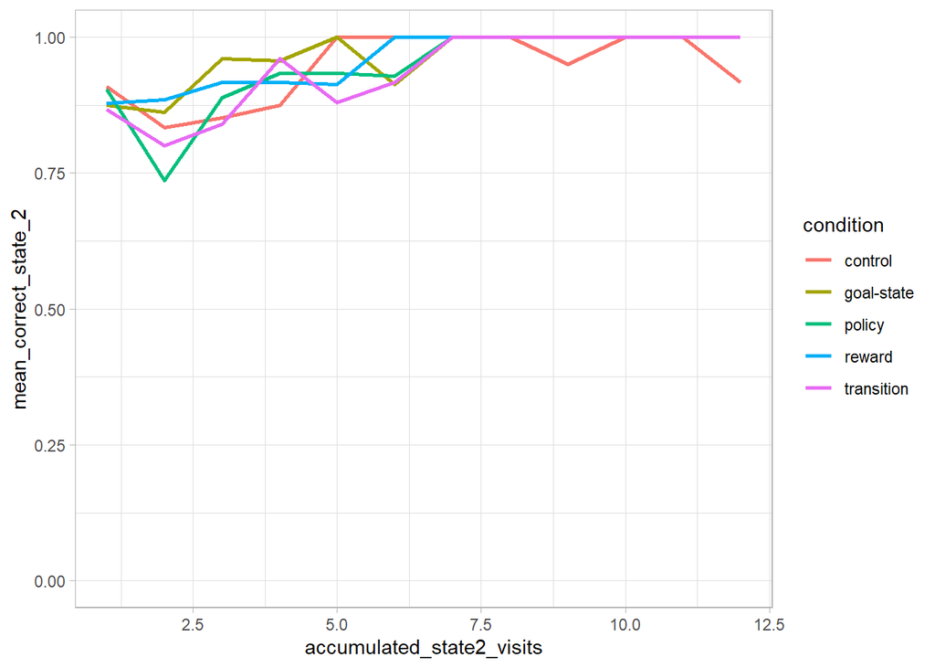

```r
# bar plot state 1
ggplot(learning_state2_correct_component_time_df, aes(x=accumulated_state2_visits, y=mean_correct_state_2, fill=condition)) +
  geom_line(aes(color=condition), size=1) +
  scale_y_continuous(limits = c(0, 1)) +
  theme_light() +
  scale_fill_manual(values=c('lightblue','#E69F00','seagreen','grey','pink'))
```

### Percent correct state 3 over time

- ceiling effect after ~ half of trials

```r
# get percent correct over time
learning_state3_correct_component_time_df <- trial_df %>%
  filter(phase == "learning",
         state %in% c(3)
         ) %>%
  group_by(ID, condition) %>%
  mutate(accumulated_state3_visits = row_number()
         ) %>%
  group_by(condition, accumulated_state3_visits) %>%
  summarise(mean_correct_state_3 = mean(correct_state_3, na.rm = TRUE),
            se_correct_state_3 = sd(correct_state_3, na.rm = TRUE)/sqrt(n()),
            ci_l = ci(correct_state_3, na.rm=TRUE)[2],
            ci_u = ci(correct_state_3, na.rm=TRUE)[3],
            n = n()
            )

learning_state3_correct_component_time_df %>%
  kable("html") %>%
  kable_styling(font_size = 14,
                latex_options = "scale_down")
```

| condition | accumulated_state3_visits | mean_correct_state_3 | se_correct_state_3 | ci_l | ci_u | n |
| --- | --- | --- | --- | --- | --- | --- |
| control | 1 | 0.8421053 | 0.0599468 | 0.7206415 | 0.9635691 | 38 |
| control | 2 | 0.8437500 | 0.0652133 | 0.7107466 | 0.9767534 | 32 |
| control | 3 | 0.9354839 | 0.0448530 | 0.8438818 | 1.0270860 | 31 |
| control | 4 | 0.9666667 | 0.0333333 | 0.8984923 | 1.0348410 | 30 |
| control | 5 | 0.9310345 | 0.0478872 | 0.8329419 | 1.0291271 | 29 |
| control | 6 | 0.9310345 | 0.0478872 | 0.8329419 | 1.0291271 | 29 |
| control | 7 | 1.0000000 | 0.0000000 | 1.0000000 | 1.0000000 | 28 |
| control | 8 | 1.0000000 | 0.0000000 | 1.0000000 | 1.0000000 | 27 |
| control | 9 | 1.0000000 | 0.0000000 | 1.0000000 | 1.0000000 | 26 |
| control | 10 | 0.9130435 | 0.0600739 | 0.7884579 | 1.0376290 | 23 |
| control | 11 | 1.0000000 | 0.0000000 | 1.0000000 | 1.0000000 | 20 |
| control | 12 | 1.0000000 | 0.0000000 | 1.0000000 | 1.0000000 | 17 |
| goal-state | 1 | 0.9459459 | 0.0376874 | 0.8695124 | 1.0223795 | 37 |
| goal-state | 2 | 0.9354839 | 0.0448530 | 0.8438818 | 1.0270860 | 31 |
| goal-state | 3 | 0.9032258 | 0.0539781 | 0.7929879 | 1.0134637 | 31 |
| goal-state | 4 | 0.9677419 | 0.0322581 | 0.9018622 | 1.0336217 | 31 |
| goal-state | 5 | 0.9333333 | 0.0463206 | 0.8385972 | 1.0280695 | 30 |
| goal-state | 6 | 0.9310345 | 0.0478872 | 0.8329419 | 1.0291271 | 29 |
| goal-state | 7 | 0.9629630 | 0.0370370 | 0.8868322 | 1.0390937 | 27 |
| goal-state | 8 | 0.9259259 | 0.0513611 | 0.8203516 | 1.0315002 | 27 |
| goal-state | 9 | 1.0000000 | 0.0000000 | 1.0000000 | 1.0000000 | 27 |
| goal-state | 10 | 1.0000000 | 0.0000000 | 1.0000000 | 1.0000000 | 25 |
| goal-state | 11 | 1.0000000 | 0.0000000 | 1.0000000 | 1.0000000 | 21 |
| goal-state | 12 | 1.0000000 | 0.0000000 | 1.0000000 | 1.0000000 | 18 |
| policy | 1 | 0.9024390 | 0.0469156 | 0.8076191 | 0.9972589 | 41 |
| policy | 2 | 0.8205128 | 0.0622540 | 0.6944861 | 0.9465396 | 39 |
| policy | 3 | 0.9736842 | 0.0263158 | 0.9203634 | 1.0270051 | 38 |
| policy | 4 | 1.0000000 | 0.0000000 | 1.0000000 | 1.0000000 | 38 |
| policy | 5 | 0.9210526 | 0.0443313 | 0.8312289 | 1.0108763 | 38 |
| policy | 6 | 0.9189189 | 0.0454933 | 0.8266543 | 1.0111835 | 37 |
| policy | 7 | 0.9166667 | 0.0467177 | 0.8218248 | 1.0115086 | 36 |
| policy | 8 | 0.9714286 | 0.0285714 | 0.9133644 | 1.0294927 | 35 |
| policy | 9 | 0.9714286 | 0.0285714 | 0.9133644 | 1.0294927 | 35 |
| policy | 10 | 1.0000000 | 0.0000000 | 1.0000000 | 1.0000000 | 32 |
| policy | 11 | 1.0000000 | 0.0000000 | 1.0000000 | 1.0000000 | 31 |
| policy | 12 | 1.0000000 | 0.0000000 | 1.0000000 | 1.0000000 | 29 |
| reward | 1 | 0.8648649 | 0.0569780 | 0.7493082 | 0.9804216 | 37 |
| reward | 2 | 0.9117647 | 0.0493748 | 0.8113109 | 1.0122185 | 34 |
| reward | 3 | 0.8750000 | 0.0593989 | 0.7538552 | 0.9961448 | 32 |
| reward | 4 | 0.9062500 | 0.0523515 | 0.7994785 | 1.0130215 | 32 |
| reward | 5 | 0.9032258 | 0.0539781 | 0.7929879 | 1.0134637 | 31 |
| reward | 6 | 0.9354839 | 0.0448530 | 0.8438818 | 1.0270860 | 31 |
| reward | 7 | 0.9285714 | 0.0495635 | 0.8268756 | 1.0302673 | 28 |
| reward | 8 | 1.0000000 | 0.0000000 | 1.0000000 | 1.0000000 | 27 |
| reward | 9 | 1.0000000 | 0.0000000 | 1.0000000 | 1.0000000 | 26 |
| reward | 10 | 1.0000000 | 0.0000000 | 1.0000000 | 1.0000000 | 26 |
| reward | 11 | 1.0000000 | 0.0000000 | 1.0000000 | 1.0000000 | 24 |
| reward | 12 | 1.0000000 | 0.0000000 | 1.0000000 | 1.0000000 | 17 |
| transition | 1 | 0.8285714 | 0.0646349 | 0.6972175 | 0.9599254 | 35 |
| transition | 2 | 0.8750000 | 0.0593989 | 0.7538552 | 0.9961448 | 32 |
| transition | 3 | 0.9375000 | 0.0434755 | 0.8488311 | 1.0261689 | 32 |
| transition | 4 | 0.8437500 | 0.0652133 | 0.7107466 | 0.9767534 | 32 |
| transition | 5 | 0.9032258 | 0.0539781 | 0.7929879 | 1.0134637 | 31 |
| transition | 6 | 0.9666667 | 0.0333333 | 0.8984923 | 1.0348410 | 30 |
| transition | 7 | 1.0000000 | 0.0000000 | 1.0000000 | 1.0000000 | 26 |
| transition | 8 | 1.0000000 | 0.0000000 | 1.0000000 | 1.0000000 | 25 |
| transition | 9 | 0.9600000 | 0.0400000 | 0.8774441 | 1.0425559 | 25 |
| transition | 10 | 1.0000000 | 0.0000000 | 1.0000000 | 1.0000000 | 25 |
| transition | 11 | 1.0000000 | 0.0000000 | 1.0000000 | 1.0000000 | 25 |
| transition | 12 | 1.0000000 | 0.0000000 | 1.0000000 | 1.0000000 | 20 |

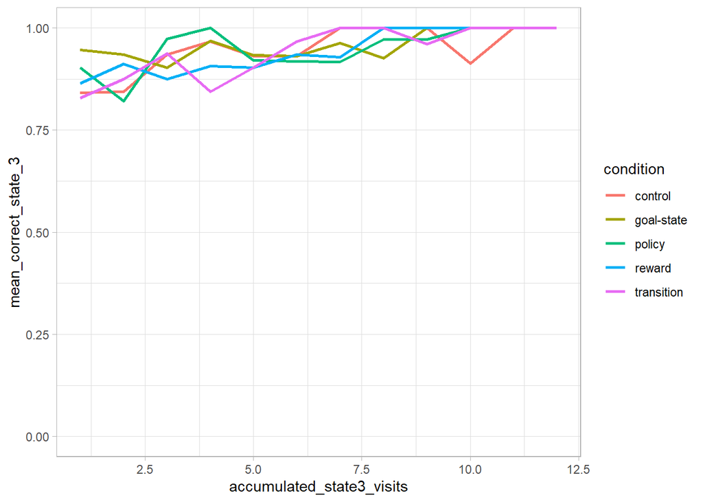

```r
# bar plot state 1
ggplot(learning_state3_correct_component_time_df, aes(x=accumulated_state3_visits, y=mean_correct_state_3, fill=condition)) +
  geom_line(aes(color=condition), size=1) +
  scale_y_continuous(limits = c(0, 1)) +
  theme_light() +
  scale_fill_manual(values=c('lightblue','#E69F00','seagreen','grey','pink'))
```

## Rule out confounding variables / alternative explanations

### Percent correct all states per condition index

- lower % correct in 1st condition
- transition revaluation lower % correct when last condition –> should be balanced out in final study (every condition equally often in every position)

```r
# get percent correct over time
learning_correct_component_index_df <- trial_df %>%
  mutate(condition_index = as.factor(condition_index)) %>%
  filter(phase == "learning",
         state %in% c(1,2,3)
         ) %>%
  group_by(component, condition_index) %>%
  summarise(mean_correct = mean(correct, na.rm = TRUE),
            se_correct = sd(correct, na.rm = TRUE)/sqrt(n()),
            ci_l = ci(correct, na.rm=TRUE)[2],
            ci_u = ci(correct, na.rm=TRUE)[3],
            n = n()
            )

learning_correct_component_index_df %>%
  kable("html") %>%
  kable_styling(font_size = 14,
                latex_options = "scale_down")
```

| component | condition_index | mean_correct | se_correct | ci_l | ci_u | n |
| --- | --- | --- | --- | --- | --- | --- |
| control-learning | 1 | 0.8541667 | 0.0228297 | 0.8091935 | 0.8991398 | 240 |
| control-learning | 2 | 0.9513889 | 0.0126942 | 0.9264033 | 0.9763745 | 288 |
| control-learning | 3 | 0.8869048 | 0.0245077 | 0.8385199 | 0.9352896 | 168 |
| control-learning | 4 | 0.9907407 | 0.0065320 | 0.9778657 | 1.0036158 | 216 |
| control-learning | 5 | 0.9409722 | 0.0139116 | 0.9135906 | 0.9683538 | 288 |
| goal-state-learning | 1 | 0.8437500 | 0.0214327 | 0.8015649 | 0.8859351 | 288 |
| goal-state-learning | 2 | 0.9166667 | 0.0213873 | 0.8744423 | 0.9588911 | 168 |
| goal-state-learning | 3 | 0.9907407 | 0.0065320 | 0.9778657 | 1.0036158 | 216 |
| goal-state-learning | 4 | 0.9513889 | 0.0126942 | 0.9264033 | 0.9763745 | 288 |
| goal-state-learning | 5 | 0.9666667 | 0.0116112 | 0.9437932 | 0.9895401 | 240 |
| policy-learning | 1 | 0.8452381 | 0.0279874 | 0.7899833 | 0.9004929 | 168 |
| policy-learning | 2 | 0.9814815 | 0.0091944 | 0.9633587 | 0.9996043 | 216 |
| policy-learning | 3 | 0.9618056 | 0.0113137 | 0.9395373 | 0.9840738 | 288 |
| policy-learning | 4 | 0.9416667 | 0.0151603 | 0.9118018 | 0.9715316 | 240 |
| policy-learning | 5 | 0.9548611 | 0.0122548 | 0.9307405 | 0.9789817 | 288 |
| reward-learning | 1 | 0.8784722 | 0.0192868 | 0.8405106 | 0.9164338 | 288 |
| reward-learning | 2 | 0.9625000 | 0.0122890 | 0.9382914 | 0.9867086 | 240 |
| reward-learning | 3 | 0.9652778 | 0.0108066 | 0.9440075 | 0.9865480 | 288 |
| reward-learning | 4 | 0.8511905 | 0.0275404 | 0.7968182 | 0.9055627 | 168 |
| reward-learning | 5 | 0.9768519 | 0.0102554 | 0.9566378 | 0.9970659 | 216 |
| transition-learning | 1 | 0.9166667 | 0.0188493 | 0.8795135 | 0.9538198 | 216 |
| transition-learning | 2 | 0.9583333 | 0.0117954 | 0.9351169 | 0.9815497 | 288 |
| transition-learning | 3 | 0.9500000 | 0.0140977 | 0.9222284 | 0.9777716 | 240 |
| transition-learning | 4 | 0.9479167 | 0.0131158 | 0.9221014 | 0.9737319 | 288 |
| transition-learning | 5 | 0.8214286 | 0.0296369 | 0.7629173 | 0.8799398 | 168 |

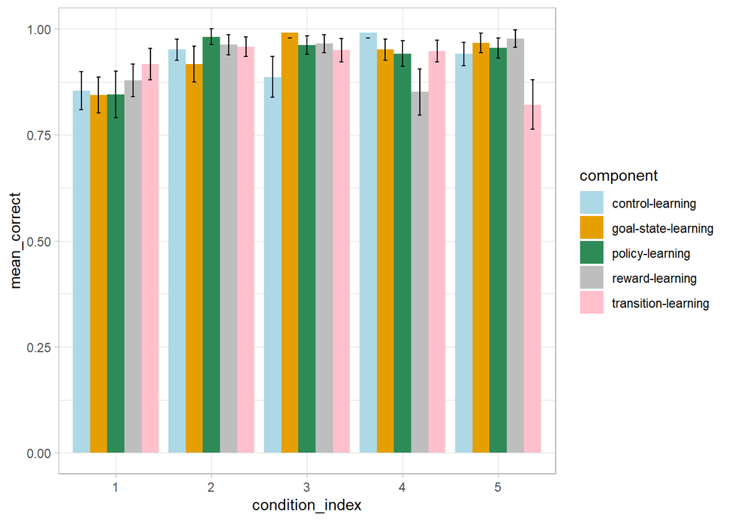

```r
# bar plot
ggplot(learning_correct_component_index_df, aes(x=condition_index, y=mean_correct, fill=component)) +
  geom_bar(stat="identity", position=position_dodge()) +
  geom_errorbar(aes(ymin=ci_l, ymax=ci_u), width=.2, position=position_dodge(.9)) +
  scale_y_continuous(limits = c(0, 1)) +
  theme_light() +
  scale_fill_manual(values=c('lightblue','#E69F00','seagreen','grey','pink'))
```

### Percent correct all states per environment

- no consistent effects
- differences should be balanced out in final study (every condition equally often paired with every environment)

```r
# get percent correct over time
learning_correct_component_environment_df <- trial_df %>%
  mutate(environment = as.factor(environment)) %>%
  filter(phase == "learning",
         state %in% c(1,2,3)
         ) %>%
  group_by(component, environment) %>%
  summarise(mean_correct = mean(correct, na.rm = TRUE),
            se_correct = sd(correct, na.rm = TRUE)/sqrt(n()),
            ci_l = ci(correct, na.rm=TRUE)[2],
            ci_u = ci(correct, na.rm=TRUE)[3],
            n = n()
            )

learning_correct_component_environment_df %>%
  kable("html") %>%
  kable_styling(font_size = 14,
                latex_options = "scale_down")
```

| component | environment | mean_correct | se_correct | ci_l | ci_u | n |
| --- | --- | --- | --- | --- | --- | --- |
| control-learning | blue_floral | 0.9114583 | 0.0205554 | 0.8709136 | 0.9520030 | 192 |
| control-learning | messy_green | 0.9583333 | 0.0136280 | 0.9314717 | 0.9851950 | 216 |
| control-learning | orange_tile | 0.8782051 | 0.0185452 | 0.8417151 | 0.9146951 | 312 |
| control-learning | red_brown | 0.9218750 | 0.0194184 | 0.8835729 | 0.9601771 | 192 |
| control-learning | white_modern | 0.9722222 | 0.0097004 | 0.9531292 | 0.9913152 | 288 |
| goal-state-learning | blue_floral | 0.9861111 | 0.0079814 | 0.9703794 | 1.0018429 | 216 |
| goal-state-learning | messy_green | 0.9294872 | 0.0145170 | 0.9009233 | 0.9580510 | 312 |
| goal-state-learning | orange_tile | 0.8958333 | 0.0221035 | 0.8522350 | 0.9394317 | 192 |
| goal-state-learning | red_brown | 0.8993056 | 0.0177630 | 0.8643434 | 0.9342678 | 288 |
| goal-state-learning | white_modern | 0.9531250 | 0.0152943 | 0.9229576 | 0.9832924 | 192 |
| policy-learning | blue_floral | 0.9230769 | 0.0151101 | 0.8933460 | 0.9528079 | 312 |
| policy-learning | messy_green | 0.9166667 | 0.0199985 | 0.8772203 | 0.9561130 | 192 |
| policy-learning | orange_tile | 0.9409722 | 0.0139116 | 0.9135906 | 0.9683538 | 288 |
| policy-learning | red_brown | 0.9531250 | 0.0152943 | 0.9229576 | 0.9832924 | 192 |
| policy-learning | white_modern | 0.9907407 | 0.0065320 | 0.9778657 | 1.0036158 | 216 |
| reward-learning | blue_floral | 0.9513889 | 0.0126942 | 0.9264033 | 0.9763745 | 288 |
| reward-learning | messy_green | 0.9687500 | 0.0125897 | 0.9439174 | 0.9935826 | 192 |
| reward-learning | orange_tile | 0.9537037 | 0.0143305 | 0.9254575 | 0.9819499 | 216 |
| reward-learning | red_brown | 0.9038462 | 0.0167167 | 0.8709540 | 0.9367383 | 312 |
| reward-learning | white_modern | 0.8750000 | 0.0239300 | 0.8277990 | 0.9222010 | 192 |
| transition-learning | blue_floral | 0.8177083 | 0.0279361 | 0.7626054 | 0.8728112 | 192 |
| transition-learning | messy_green | 0.9513889 | 0.0126942 | 0.9264033 | 0.9763745 | 288 |
| transition-learning | orange_tile | 0.9687500 | 0.0125897 | 0.9439174 | 0.9935826 | 192 |
| transition-learning | red_brown | 0.9861111 | 0.0079814 | 0.9703794 | 1.0018429 | 216 |
| transition-learning | white_modern | 0.9070513 | 0.0164648 | 0.8746547 | 0.9394478 | 312 |

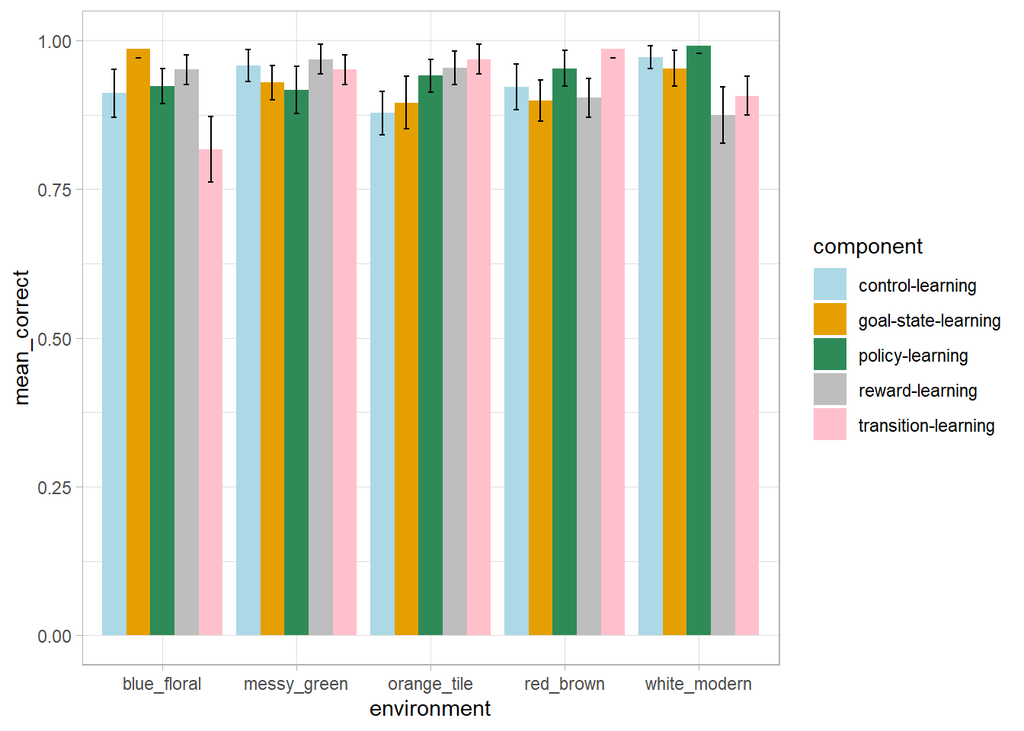

```r
# bar plot
ggplot(learning_correct_component_environment_df, aes(x=environment, y=mean_correct, fill=component)) +
  geom_bar(stat="identity", position=position_dodge()) +
  geom_errorbar(aes(ymin=ci_l, ymax=ci_u), width=.2, position=position_dodge(.9)) +
  scale_y_continuous(limits = c(0, 1)) +
  theme_light() +
  scale_fill_manual(values=c('lightblue','#E69F00','seagreen','grey','pink'))
```

### Balancing check: variations

- variations = latin square matching between condition order and environment order
- mostly successful

```r
# get percent correct over time
balancing_variations_df <- component_df %>%
  filter(component == "control-learning"
         ) %>%
  group_by(variation) %>%
  summarise(n = n()
            )

balancing_variations_df %>%
  kable("html") %>%
  kable_styling(font_size = 14,
                latex_options = "scale_down")
```

| variation | n |
| --- | --- |
| A1 | 3 |
| A2 | 3 |
| A3 | 1 |
| A4 | 2 |
| A5 | 3 |
| B1 | 2 |
| B2 | 1 |
| B3 | 2 |
| B4 | 2 |
| B5 | 2 |
| C1 | 1 |
| C2 | 2 |
| C3 | 1 |
| C4 | 2 |
| C5 | 1 |
| D1 | 2 |
| D2 | 2 |
| D3 | 3 |
| D4 | 2 |
| D5 | 3 |
| E1 | 2 |
| E2 | 2 |
| E3 | 2 |
| E4 | 3 |
| E5 | 1 |

### Balancing check: Condition index per condition

- mostly successful
- in final study, we should collect data until equal n per cell

```r
# get percent correct over time
balancing_index_df <- component_df %>%
  mutate(condition_index = as.factor(condition_index)) %>%
  filter(phase == "learning"
         ) %>%
  group_by(component, condition_index) %>%
  summarise(n = n()
            )

balancing_index_df %>%
  kable("html") %>%
  kable_styling(font_size = 14,
                latex_options = "scale_down")
```

| component | condition_index | n |
| --- | --- | --- |
| control-learning | 1 | 10 |
| control-learning | 2 | 12 |
| control-learning | 3 | 7 |
| control-learning | 4 | 9 |
| control-learning | 5 | 12 |
| goal-state-learning | 1 | 12 |
| goal-state-learning | 2 | 7 |
| goal-state-learning | 3 | 9 |
| goal-state-learning | 4 | 12 |
| goal-state-learning | 5 | 10 |
| policy-learning | 1 | 7 |
| policy-learning | 2 | 9 |
| policy-learning | 3 | 12 |
| policy-learning | 4 | 10 |
| policy-learning | 5 | 12 |
| reward-learning | 1 | 12 |
| reward-learning | 2 | 10 |
| reward-learning | 3 | 12 |
| reward-learning | 4 | 7 |
| reward-learning | 5 | 9 |
| transition-learning | 1 | 9 |
| transition-learning | 2 | 12 |
| transition-learning | 3 | 10 |
| transition-learning | 4 | 12 |
| transition-learning | 5 | 7 |

### Balancing check: Condition index per environment

- mostly successful
- in final study, we should collect data until equal n per cell

```r
# get percent correct over time
balancing_environment_df <- component_df %>%
  mutate(condition_index = as.factor(condition_index)) %>%
  filter(phase == "learning"
         ) %>%
  group_by(condition_index, environment) %>%
  summarise(n = n()
            )

balancing_environment_df %>%
  kable("html") %>%
  kable_styling(font_size = 14,
                latex_options = "scale_down")
```

| condition_index | environment | n |
| --- | --- | --- |
| 1 | blue_floral | 10 |
| 1 | messy_green | 9 |
| 1 | orange_tile | 11 |
| 1 | red_brown | 10 |
| 1 | white_modern | 10 |
| 2 | blue_floral | 10 |
| 2 | messy_green | 10 |
| 2 | orange_tile | 9 |
| 2 | red_brown | 11 |
| 2 | white_modern | 10 |
| 3 | blue_floral | 10 |
| 3 | messy_green | 10 |
| 3 | orange_tile | 10 |
| 3 | red_brown | 9 |
| 3 | white_modern | 11 |
| 4 | blue_floral | 11 |
| 4 | messy_green | 10 |
| 4 | orange_tile | 10 |
| 4 | red_brown | 10 |
| 4 | white_modern | 9 |
| 5 | blue_floral | 9 |
| 5 | messy_green | 11 |
| 5 | orange_tile | 10 |
| 5 | red_brown | 10 |
| 5 | white_modern | 10 |

## Inclusion / Exclusion

### Criterion: >2 correct choices in each of last 4 state 1,2,3 visits

```r
# get last 4 choices per state
learning_state1_last4_df <- trial_df %>%
  filter(phase == "learning",
         state == 1) %>%
  group_by(ID, component) %>%
  slice_tail(n=4)

learning_state2_last4_df <- trial_df %>%
  filter(phase == "learning",
         state == 2) %>%
  group_by(ID, component) %>%
  slice_tail(n=4)

learning_state3_last4_df <- trial_df %>%
  filter(phase == "learning",
         state == 3) %>%
  group_by(ID, component) %>%
  slice_tail(n=4)

# who does not pass state 1 criterion
learning_state1_last4_correct_component_df <- learning_state1_last4_df %>%
  group_by(ID, component, condition_index, condition, environment) %>%
  summarise(sum_correct = sum(correct_state_1))

learning_state1_last4_correct_component_df_excl <- learning_state1_last4_correct_component_df %>%
  filter(sum_correct < 3) %>%
  mutate(ID_condition_combo = paste(ID, "-", condition, sep=""))

# who does not pass state 2 criterion
learning_state2_last4_correct_component_df <- learning_state2_last4_df %>%
  group_by(ID, component, condition_index, condition, environment) %>%
  summarise(sum_correct = sum(correct_state_2))

learning_state2_last4_correct_component_df_excl <- learning_state2_last4_correct_component_df %>%
  filter(sum_correct < 3) %>%
  mutate(ID_condition_combo = paste(ID, "-", condition, sep=""))

# who does not pass state 3 criterion
learning_state3_last4_correct_component_df <- learning_state3_last4_df %>%
  group_by(ID, component, condition_index, condition, environment) %>%
  summarise(sum_correct = sum(correct_state_3))

learning_state3_last4_correct_component_df_excl <- learning_state3_last4_correct_component_df %>%
  filter(sum_correct < 3) %>%
  mutate(ID_condition_combo = paste(ID, "-", condition, sep=""))

# excluded components
learning_last4_correct_component_df_excl <- rbind(learning_state1_last4_correct_component_df_excl,
                                          learning_state2_last4_correct_component_df_excl,
                                          learning_state3_last4_correct_component_df_excl)

learning_last4_correct_component_df_excl <- learning_last4_correct_component_df_excl %>%
  select(! sum_correct) %>%
  distinct()

excluded_components_a <- learning_last4_correct_component_df_excl$ID_condition_combo

percent_component_excluded_a <- length(excluded_components_a)/nrow(learning_state1_last4_correct_component_df)

# excluded subjects
excluded_IDs_a <- unique(learning_last4_correct_component_df_excl$ID)

percent_IDs_excluded_a <- length(excluded_IDs_a)/length(unique(trial_df$ID))
```

- % excluded components

```r
percent_component_excluded_a
```

```
[1] 0.32
```

- % excluded IDs

```r
percent_IDs_excluded_a
```

```
[1] 0.72
```

- Even though >90% correct in learning, we still loose a lot of participants when applying the original exclusion criterion

#### Excluded components per condition

- we loose most participants in reward/goal-state/control
- transition/policy might be easier to learn as both rewards follow the same state 1 action

```r
learning_last4_correct_condition_df_excl <- learning_last4_correct_component_df_excl %>%
  group_by(condition) %>%
  summarise(n = n()
            )

learning_last4_correct_condition_df_excl %>%
  kable("html") %>%
  kable_styling(font_size = 18,
                latex_options = "scale_down")
```

| condition | n |
| --- | --- |
| control | 19 |
| goal-state | 18 |
| policy | 12 |
| reward | 18 |
| transition | 13 |

#### Excluded components per component index

- we loose most participants in the first condition

```r
learning_last4_correct_component_index_df_excl <- learning_last4_correct_component_df_excl %>%
  group_by(condition_index) %>%
  summarise(n = n()
            )

learning_last4_correct_component_index_df_excl %>%
  kable("html") %>%
  kable_styling(font_size = 18,
                latex_options = "scale_down")
```

| condition_index | n |
| --- | --- |
| 1 | 27 |
| 2 | 12 |
| 3 | 13 |
| 4 | 14 |
| 5 | 14 |

#### Excluded components per environment

- we loose most participants in the orange_tile environment –> should be balanced out

```r
learning_last4_correct_component_environment_df_excl <- learning_last4_correct_component_df_excl %>%
  group_by(environment) %>%
  summarise(n = n()
            )

learning_last4_correct_component_environment_df_excl %>%
  kable("html") %>%
  kable_styling(font_size = 18,
                latex_options = "scale_down")
```

| environment | n |
| --- | --- |
| blue_floral | 16 |
| messy_green | 18 |
| orange_tile | 21 |
| red_brown | 13 |
| white_modern | 12 |

```r
# get choices per state
learning_state1_df <- trial_df %>%
  filter(phase == "learning",
         state == 1)

learning_state2_df <- trial_df %>%
  filter(phase == "learning",
         state == 2)

learning_state3_df <- trial_df %>%
  filter(phase == "learning",
         state == 3)

# who does not pass state 1 criterion
learning_state1_correct_component_df <- learning_state1_df %>%
  group_by(ID, component, condition_index, condition, environment) %>%
  summarise(mean_correct = mean(correct_state_1))

learning_state1_correct_component_df_excl <- learning_state1_correct_component_df %>%
  filter(mean_correct < 0.65) %>%
  mutate(ID_condition_combo = paste(ID, "-", condition, sep=""))

# who does not pass state 2 criterion
learning_state2_correct_component_df <- learning_state2_df %>%
  group_by(ID, component, condition_index, condition, environment) %>%
  summarise(mean_correct = mean(correct_state_2))

learning_state2_correct_component_df_excl <- learning_state2_correct_component_df %>%
  filter(mean_correct < 0.65) %>%
  mutate(ID_condition_combo = paste(ID, "-", condition, sep=""))

# who does not pass state 3 criterion
learning_state3_correct_component_df <- learning_state3_df %>%
  group_by(ID, component, condition_index, condition, environment) %>%
  summarise(mean_correct = mean(correct_state_3))

learning_state3_correct_component_df_excl <- learning_state3_correct_component_df %>%
  filter(mean_correct < 0.65) %>%
  mutate(ID_condition_combo = paste(ID, "-", condition, sep=""))

# excluded components
learning_correct_component_df_excl <- rbind(learning_state1_correct_component_df_excl,
                                          learning_state2_correct_component_df_excl,
                                          learning_state3_correct_component_df_excl)

learning_correct_component_df_excl <- learning_correct_component_df_excl %>%
  select(! mean_correct) %>%
  distinct()

excluded_components_b <- learning_correct_component_df_excl$ID_condition_combo

percent_component_excluded_b <- length(excluded_components_b)/nrow(learning_state1_correct_component_df)

# how many subjects don't pass criterion in at least one condition
excluded_IDs_b <- unique(learning_correct_component_df_excl$ID)

percent_IDs_excluded_b <- length(excluded_IDs_b)/length(unique(trial_df$ID))
```

- % excluded components

```r
percent_component_excluded_b
```

```
[1] 0.16
```

- % excluded IDs

```r
percent_IDs_excluded_b
```

```
[1] 0.4
```

#### Excluded components per condition

```r
learning_correct_condition_df_excl <- learning_correct_component_df_excl %>%
  group_by(condition) %>%
  summarise(n = n()
            )

learning_correct_condition_df_excl %>%
  kable("html") %>%
  kable_styling(font_size = 18,
                latex_options = "scale_down")
```

| condition | n |
| --- | --- |
| control | 7 |
| goal-state | 8 |
| policy | 6 |
| reward | 9 |
| transition | 10 |

#### Excluded components per component index

```r
learning_correct_component_index_df_excl <- learning_correct_component_df_excl %>%
  group_by(condition_index) %>%
  summarise(n = n()
            )

learning_correct_component_index_df_excl %>%
  kable("html") %>%
  kable_styling(font_size = 18,
                latex_options = "scale_down")
```

| condition_index | n |
| --- | --- |
| 1 | 14 |
| 2 | 7 |
| 3 | 6 |
| 4 | 6 |
| 5 | 7 |

#### Excluded components per environment

```r
learning_correct_component_environment_df_excl <- learning_correct_component_df_excl %>%
  group_by(environment) %>%
  summarise(n = n()
            )

learning_correct_component_environment_df_excl %>%
  kable("html") %>%
  kable_styling(font_size = 18,
                latex_options = "scale_down")
```

| environment | n |
| --- | --- |
| blue_floral | 9 |
| messy_green | 9 |
| orange_tile | 8 |
| red_brown | 9 |
| white_modern | 5 |

### Final exclusion

```r
################ CHOOSE EXCLUSION CRITERION ####################################
################################################################################

excluded_components <- excluded_components_b # a or b
excluded_IDs <- excluded_IDs_b # a or b
```

```r
# # Exclude components from all dfs
# trial_df_excl <- trial_df %>%
#   mutate(ID_condition_combo = paste(ID, "-", condition, sep="")) %>%
#   filter(! ID_condition_combo %in% excluded_components)
#
# component_df_excl <- component_df %>%
#   mutate(ID_condition_combo = paste(ID, "-", condition, sep="")) %>%
#   filter(! ID_condition_combo %in% excluded_components)
```

```r
# OR Exclude IDs from all dfs
trial_df_excl <- trial_df %>%
  filter(! ID %in% excluded_IDs)

component_df_excl <- component_df %>%
  filter(! ID %in% excluded_IDs)

rating_df_excl <- rating_df %>%
  filter(! ID %in% excluded_IDs)
```

```r
################ DF DEFINITION FOR RELEARNING & TEST ########################
#############################################################################

df <- trial_df_excl # trial_df, trial_df_excl
```

- Further analyses based on n =

```r
length(unique(df$ID))
```

```
[1] 30
```

# Test Phase

## State 1

### State 1 switches in all 5 test trials per component

- % switches (from state 1 optimal learning action to state 1 optimal test action) in reward > transition revaluation
- but % switches in policy more comparable to reward than to transition revaluation -> participants might have used a MB strategy with a higher learning rate for the weight vector compared to the transition matrix

```r
test_switch_component_df <- df %>%
  filter(phase == "test",
         state == 1) %>%
  group_by(component) %>%
  summarise(n = n(),
            sum_switch = sum(switch, na.rm=T),
            percent_switch = mean(switch, na.rm=T),
            se_switch = sd(switch, na.rm = TRUE)/sqrt(n()),
            ci_l = ci(switch, na.rm=TRUE)[2],
            ci_u = ci(switch, na.rm=TRUE)[3]
            )

test_switch_component_df %>%
  kable("html") %>%
  kable_styling(font_size = 18,
                latex_options = "scale_down")
```

| component | n | sum_switch | percent_switch | se_switch | ci_l | ci_u |
| --- | --- | --- | --- | --- | --- | --- |
| control-test | 150 | 12 | 0.0800000 | 0.0222252 | 0.0360827 | 0.1239173 |
| goal-state-test | 150 | 117 | 0.7800000 | 0.0339364 | 0.7129413 | 0.8470587 |
| policy-test | 150 | 121 | 0.8066667 | 0.0323525 | 0.7427378 | 0.8705956 |
| reward-test | 150 | 121 | 0.8066667 | 0.0323525 | 0.7427378 | 0.8705956 |
| transition-test | 150 | 65 | 0.4333333 | 0.0405959 | 0.3531154 | 0.5135513 |

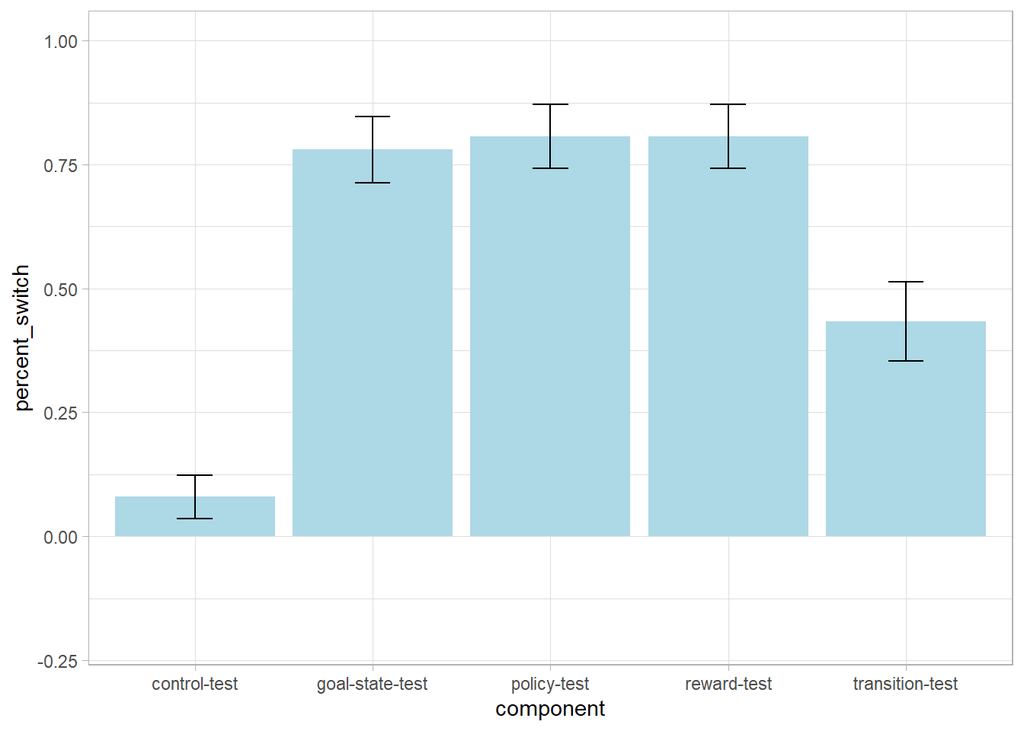

```r
# bar plot
ggplot(test_switch_component_df, aes(x=component, y=percent_switch)) +
  geom_bar(stat="identity", fill="lightblue") +
  geom_errorbar(aes(ymin=ci_l, ymax=ci_u), width=.2, position=position_dodge(.9)) +
  scale_y_continuous(limits = c(-0.2, 1)) +
  theme_light()
```

#### LogReg: Difference from control condition

```r
logreg_test_switch_condition_df <- df %>%
  filter(phase == "test") %>%
  mutate(switch = as.factor(switch),
         condition = as.factor(condition)) %>%
  select(ID,
         switch,
         condition)

contrasts(logreg_test_switch_condition_df$condition) <- contr.treatment(5, base = 1)

log_model_control <- glmer(switch ~ condition + (1 | ID), data = logreg_test_switch_condition_df, family = "binomial")
tab_model(log_model_control, transform = NULL, show.est = T, show.stat = T, auto.label = FALSE, CSS = list(css.table = '+font-size: 14;'))
```

|  | switch |  |  |  |
| --- | --- | --- | --- | --- |
| Predictors | Log-Odds | CI | Statistic | p |
| (Intercept) | -2.74 | -3.45 – -2.04 | -7.62 | **<0.001** |
| condition2 | 4.20 | 3.41 – 4.98 | 10.50 | **<0.001** |
| condition3 | 4.38 | 3.58 – 5.17 | 10.79 | **<0.001** |
| condition4 | 4.38 | 3.58 – 5.17 | 10.79 | **<0.001** |
| condition5 | 2.44 | 1.71 – 3.16 | 6.60 | **<0.001** |
| Random Effects |  |  |  |  |
| σ<sup>2</sup> | 3.29 |  |  |  |
| τ<sub>00</sub> <sub>ID</sub> | 0.73 |  |  |  |
| ICC | 0.18 |  |  |  |
| N <sub>ID</sub> | 30 |  |  |  |
| Observations | 750 |  |  |  |
| Marginal R<sup>2</sup> / Conditional R<sup>2</sup> | 0.420 / 0.525 |  |  |  |

#### LogReg: Difference from goal-state condition

```r
contrasts(logreg_test_switch_condition_df$condition) <- contr.treatment(5, base = 2)

log_model_goalstate <- glmer(switch ~ condition + (1 | ID), data = logreg_test_switch_condition_df, family = "binomial")
tab_model(log_model_goalstate, transform = NULL, show.est = T, show.stat = T, auto.label = FALSE, CSS = list(css.table = '+font-size: 14;'))
```

|  | switch |  |  |  |
| --- | --- | --- | --- | --- |
| Predictors | Log-Odds | CI | Statistic | p |
| (Intercept) | 1.45 | 0.94 – 1.97 | 5.51 | **<0.001** |
| condition1 | -4.20 | -4.98 – -3.41 | -10.50 | **<0.001** |
| condition3 | 0.18 | -0.41 – 0.77 | 0.60 | 0.547 |
| condition4 | 0.18 | -0.41 – 0.77 | 0.60 | 0.547 |
| condition5 | -1.76 | -2.31 – -1.21 | -6.30 | **<0.001** |
| Random Effects |  |  |  |  |
| σ<sup>2</sup> | 3.29 |  |  |  |
| τ<sub>00</sub> <sub>ID</sub> | 0.73 |  |  |  |
| ICC | 0.18 |  |  |  |
| N <sub>ID</sub> | 30 |  |  |  |
| Observations | 750 |  |  |  |
| Marginal R<sup>2</sup> / Conditional R<sup>2</sup> | 0.420 / 0.525 |  |  |  |

#### LogReg: Difference from policy condition

```r
contrasts(logreg_test_switch_condition_df$condition) <- contr.treatment(5, base = 3)

log_model_reward <- glmer(switch ~ condition + (1 | ID), data = logreg_test_switch_condition_df, family = "binomial")
tab_model(log_model_reward, transform = NULL, show.est = T, show.stat = T, auto.label = FALSE, CSS = list(css.table = '+font-size: 14;'))
```

|  | switch |  |  |  |
| --- | --- | --- | --- | --- |
| Predictors | Log-Odds | CI | Statistic | p |
| (Intercept) | 1.63 | 1.10 – 2.17 | 6.01 | **<0.001** |
| condition1 | -4.38 | -5.17 – -3.58 | -10.79 | **<0.001** |
| condition2 | -0.18 | -0.77 – 0.41 | -0.60 | 0.547 |
| condition4 | 0.00 | -0.60 – 0.60 | 0.00 | 1.000 |
| condition5 | -1.94 | -2.50 – -1.38 | -6.76 | **<0.001** |
| Random Effects |  |  |  |  |
| σ<sup>2</sup> | 3.29 |  |  |  |
| τ<sub>00</sub> <sub>ID</sub> | 0.73 |  |  |  |
| ICC | 0.18 |  |  |  |
| N <sub>ID</sub> | 30 |  |  |  |
| Observations | 750 |  |  |  |
| Marginal R<sup>2</sup> / Conditional R<sup>2</sup> | 0.420 / 0.525 |  |  |  |

#### LogReg: Difference from reward condition

```r
contrasts(logreg_test_switch_condition_df$condition) <- contr.treatment(5, base = 4)

log_model_transition <- glmer(switch ~ condition + (1 | ID), data = logreg_test_switch_condition_df, family = "binomial")
tab_model(log_model_transition, transform = NULL, show.est = T, show.stat = T, auto.label = FALSE, CSS = list(css.table = '+font-size: 14;'))
```

|  | switch |  |  |  |
| --- | --- | --- | --- | --- |
| Predictors | Log-Odds | CI | Statistic | p |
| (Intercept) | 1.63 | 1.10 – 2.17 | 6.01 | **<0.001** |
| condition1 | -4.38 | -5.17 – -3.58 | -10.79 | **<0.001** |
| condition2 | -0.18 | -0.77 – 0.41 | -0.60 | 0.547 |
| condition3 | 0.00 | -0.60 – 0.60 | 0.00 | 1.000 |
| condition5 | -1.94 | -2.50 – -1.38 | -6.76 | **<0.001** |
| Random Effects |  |  |  |  |
| σ<sup>2</sup> | 3.29 |  |  |  |
| τ<sub>00</sub> <sub>ID</sub> | 0.73 |  |  |  |
| ICC | 0.18 |  |  |  |
| N <sub>ID</sub> | 30 |  |  |  |
| Observations | 750 |  |  |  |
| Marginal R<sup>2</sup> / Conditional R<sup>2</sup> | 0.420 / 0.525 |  |  |  |

#### LogReg: Difference from transition condition

```r
contrasts(logreg_test_switch_condition_df$condition) <- contr.treatment(5, base = 5)

log_model_transition <- glmer(switch ~ condition + (1 | ID), data = logreg_test_switch_condition_df, family = "binomial")
tab_model(log_model_transition, transform = NULL, show.est = T, show.stat = T, auto.label = FALSE, CSS = list(css.table = '+font-size: 14;'))
```

|  | switch |  |  |  |
| --- | --- | --- | --- | --- |
| Predictors | Log-Odds | CI | Statistic | p |
| (Intercept) | -0.31 | -0.77 – 0.16 | -1.29 | 0.197 |
| condition1 | -2.44 | -3.16 – -1.71 | -6.60 | **<0.001** |
| condition2 | 1.76 | 1.21 – 2.31 | 6.30 | **<0.001** |
| condition3 | 1.94 | 1.38 – 2.50 | 6.76 | **<0.001** |
| condition4 | 1.94 | 1.38 – 2.50 | 6.76 | **<0.001** |
| Random Effects |  |  |  |  |
| σ<sup>2</sup> | 3.29 |  |  |  |
| τ<sub>00</sub> <sub>ID</sub> | 0.73 |  |  |  |
| ICC | 0.18 |  |  |  |
| N <sub>ID</sub> | 30 |  |  |  |
| Observations | 750 |  |  |  |
| Marginal R<sup>2</sup> / Conditional R<sup>2</sup> | 0.420 / 0.525 |  |  |  |

### State 1 % switches across 5 test trials within participant per component

- same pattern as when considering all test trials across participants
- large variation in % correct transition revaluation between participants

```r
test_switch_ID_component_df <- df %>%
  filter(phase == "test",
         state == 1) %>%
  group_by(ID, component) %>%
  summarise(n = n(),
            sum_switch = sum(switch, na.rm=T),
            percent_switch = mean(switch, na.rm=T),
            se_switch = sd(switch, na.rm = TRUE)/sqrt(n()),
            ci_l = ci(switch, na.rm=TRUE)[2],
            ci_u = ci(switch, na.rm=TRUE)[3]
            )

test_switch_ID_component_df %>%
  kable("html") %>%
  kable_styling(font_size = 18,
                latex_options = "scale_down")
```

| ID | component | n | sum_switch | percent_switch | se_switch | ci_l | ci_u |
| --- | --- | --- | --- | --- | --- | --- | --- |
| 1010 | control-test | 5 | 2 | 0.4 | 0.244949 | -0.2800874 | 1.080087 |
| 1010 | goal-state-test | 5 | 3 | 0.6 | 0.244949 | -0.0800874 | 1.280087 |
| 1010 | policy-test | 5 | 2 | 0.4 | 0.244949 | -0.2800874 | 1.080087 |
| 1010 | reward-test | 5 | 3 | 0.6 | 0.244949 | -0.0800874 | 1.280087 |
| 1010 | transition-test | 5 | 2 | 0.4 | 0.244949 | -0.2800874 | 1.080087 |
| 1337 | control-test | 5 | 0 | 0.0 | 0.000000 | 0.0000000 | 0.000000 |
| 1337 | goal-state-test | 5 | 5 | 1.0 | 0.000000 | 1.0000000 | 1.000000 |
| 1337 | policy-test | 5 | 5 | 1.0 | 0.000000 | 1.0000000 | 1.000000 |
| 1337 | reward-test | 5 | 4 | 0.8 | 0.200000 | 0.2447110 | 1.355289 |
| 1337 | transition-test | 5 | 0 | 0.0 | 0.000000 | 0.0000000 | 0.000000 |
| 1725 | control-test | 5 | 0 | 0.0 | 0.000000 | 0.0000000 | 0.000000 |
| 1725 | goal-state-test | 5 | 5 | 1.0 | 0.000000 | 1.0000000 | 1.000000 |
| 1725 | policy-test | 5 | 5 | 1.0 | 0.000000 | 1.0000000 | 1.000000 |
| 1725 | reward-test | 5 | 0 | 0.0 | 0.000000 | 0.0000000 | 0.000000 |
| 1725 | transition-test | 5 | 0 | 0.0 | 0.000000 | 0.0000000 | 0.000000 |
| 1965 | control-test | 5 | 0 | 0.0 | 0.000000 | 0.0000000 | 0.000000 |
| 1965 | goal-state-test | 5 | 5 | 1.0 | 0.000000 | 1.0000000 | 1.000000 |
| 1965 | policy-test | 5 | 5 | 1.0 | 0.000000 | 1.0000000 | 1.000000 |
| 1965 | reward-test | 5 | 5 | 1.0 | 0.000000 | 1.0000000 | 1.000000 |
| 1965 | transition-test | 5 | 3 | 0.6 | 0.244949 | -0.0800874 | 1.280087 |
| 2478 | control-test | 5 | 0 | 0.0 | 0.000000 | 0.0000000 | 0.000000 |
| 2478 | goal-state-test | 5 | 0 | 0.0 | 0.000000 | 0.0000000 | 0.000000 |
| 2478 | policy-test | 5 | 2 | 0.4 | 0.244949 | -0.2800874 | 1.080087 |
| 2478 | reward-test | 5 | 5 | 1.0 | 0.000000 | 1.0000000 | 1.000000 |
| 2478 | transition-test | 5 | 2 | 0.4 | 0.244949 | -0.2800874 | 1.080087 |
| 2555 | control-test | 5 | 0 | 0.0 | 0.000000 | 0.0000000 | 0.000000 |
| 2555 | goal-state-test | 5 | 5 | 1.0 | 0.000000 | 1.0000000 | 1.000000 |
| 2555 | policy-test | 5 | 5 | 1.0 | 0.000000 | 1.0000000 | 1.000000 |
| 2555 | reward-test | 5 | 5 | 1.0 | 0.000000 | 1.0000000 | 1.000000 |
| 2555 | transition-test | 5 | 5 | 1.0 | 0.000000 | 1.0000000 | 1.000000 |

[output cut: 120 more lines]

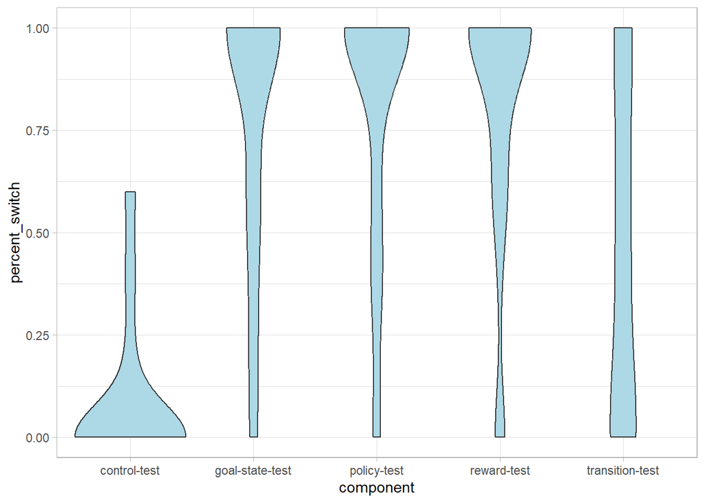

```r
# bar plot
ggplot(test_switch_ID_component_df, aes(x=component, y=percent_switch)) +
  geom_violin(fill="lightblue") +
  scale_y_continuous(labels = scales::comma) +
  theme_light()
```

### State 1 switches in first test trial per component

- same pattern as when considering all test trials across participants

```r
test_switch_component_trial1_df <- df %>%
  filter(phase == "test",
         trial == 1,
         state == 1) %>%
  group_by(component) %>%
  summarise(n = n(),
            sum_switch = sum(switch, na.rm=T),
            percent_switch = mean(switch, na.rm=T),
            se_switch = sd(switch, na.rm = TRUE)/sqrt(n()),
            ci_l = ci(switch, na.rm=TRUE)[2],
            ci_u = ci(switch, na.rm=TRUE)[3]
            )

test_switch_component_trial1_df %>%
  kable("html") %>%
  kable_styling(font_size = 18,
                latex_options = "scale_down")
```

| component | n | sum_switch | percent_switch | se_switch | ci_l | ci_u |
| --- | --- | --- | --- | --- | --- | --- |
| control-test | 30 | 0 | 0.0000000 | 0.0000000 | 0.0000000 | 0.0000000 |
| goal-state-test | 30 | 26 | 0.8666667 | 0.0631243 | 0.7375630 | 0.9957703 |
| policy-test | 30 | 24 | 0.8000000 | 0.0742781 | 0.6480842 | 0.9519158 |
| reward-test | 30 | 25 | 0.8333333 | 0.0692046 | 0.6917941 | 0.9748726 |
| transition-test | 30 | 11 | 0.3666667 | 0.0894855 | 0.1836482 | 0.5496852 |

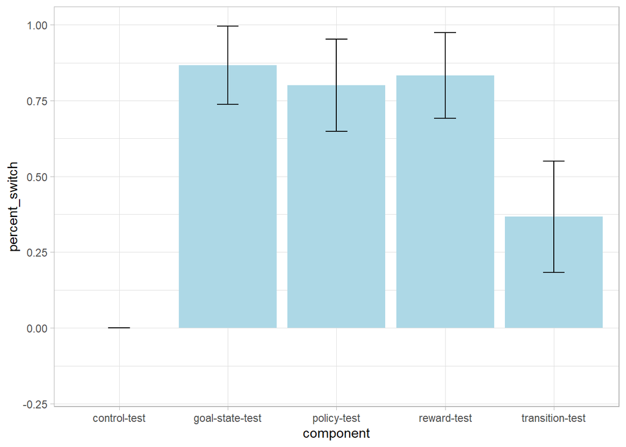

```r
# bar plot
ggplot(test_switch_component_trial1_df, aes(x=component, y=percent_switch)) +
  geom_bar(stat="identity", fill="lightblue") +
  geom_errorbar(aes(ymin=ci_l, ymax=ci_u), width=.2, position=position_dodge(.9)) +
  scale_y_continuous(limits = c(-0.2, 1)) +
  theme_light()
```

### State 1 switches per trial per component

- pattern between conditions does not depend on number of test trial (no obvious extinction effects)
- trial 1 seems to be most meaningful as lowest % switch in control condition

```r
test_switch_component_trial_df <- df %>%
  filter(phase == "test",
         state == 1) %>%
  group_by(component, trial) %>%
  summarise(n = n(),
            sum_switch = sum(switch, na.rm=T),
            percent_switch = mean(switch, na.rm=T),
            se_switch = sd(switch, na.rm = TRUE)/sqrt(n()),
            ci_l = ci(switch, na.rm=TRUE)[2],
            ci_u = ci(switch, na.rm=TRUE)[3]
            )

test_switch_component_trial_df %>%
  kable("html") %>%
  kable_styling(font_size = 18,
                latex_options = "scale_down")
```

| component | trial | n | sum_switch | percent_switch | se_switch | ci_l | ci_u |
| --- | --- | --- | --- | --- | --- | --- | --- |
| control-test | 1 | 30 | 0 | 0.0000000 | 0.0000000 | 0.0000000 | 0.0000000 |
| control-test | 2 | 30 | 3 | 0.1000000 | 0.0557086 | -0.0139369 | 0.2139369 |
| control-test | 3 | 30 | 5 | 0.1666667 | 0.0692046 | 0.0251274 | 0.3082059 |
| control-test | 4 | 30 | 2 | 0.0666667 | 0.0463206 | -0.0280695 | 0.1614028 |
| control-test | 5 | 30 | 2 | 0.0666667 | 0.0463206 | -0.0280695 | 0.1614028 |
| goal-state-test | 1 | 30 | 26 | 0.8666667 | 0.0631243 | 0.7375630 | 0.9957703 |
| goal-state-test | 2 | 30 | 24 | 0.8000000 | 0.0742781 | 0.6480842 | 0.9519158 |
| goal-state-test | 3 | 30 | 25 | 0.8333333 | 0.0692046 | 0.6917941 | 0.9748726 |
| goal-state-test | 4 | 30 | 20 | 0.6666667 | 0.0875376 | 0.4876321 | 0.8457012 |
| goal-state-test | 5 | 30 | 22 | 0.7333333 | 0.0821176 | 0.5653840 | 0.9012826 |
| policy-test | 1 | 30 | 24 | 0.8000000 | 0.0742781 | 0.6480842 | 0.9519158 |
| policy-test | 2 | 30 | 24 | 0.8000000 | 0.0742781 | 0.6480842 | 0.9519158 |
| policy-test | 3 | 30 | 23 | 0.7666667 | 0.0785403 | 0.6060337 | 0.9272997 |
| policy-test | 4 | 30 | 25 | 0.8333333 | 0.0692046 | 0.6917941 | 0.9748726 |
| policy-test | 5 | 30 | 25 | 0.8333333 | 0.0692046 | 0.6917941 | 0.9748726 |
| reward-test | 1 | 30 | 25 | 0.8333333 | 0.0692046 | 0.6917941 | 0.9748726 |
| reward-test | 2 | 30 | 24 | 0.8000000 | 0.0742781 | 0.6480842 | 0.9519158 |
| reward-test | 3 | 30 | 25 | 0.8333333 | 0.0692046 | 0.6917941 | 0.9748726 |
| reward-test | 4 | 30 | 24 | 0.8000000 | 0.0742781 | 0.6480842 | 0.9519158 |
| reward-test | 5 | 30 | 23 | 0.7666667 | 0.0785403 | 0.6060337 | 0.9272997 |
| transition-test | 1 | 30 | 11 | 0.3666667 | 0.0894855 | 0.1836482 | 0.5496852 |
| transition-test | 2 | 30 | 11 | 0.3666667 | 0.0894855 | 0.1836482 | 0.5496852 |
| transition-test | 3 | 30 | 12 | 0.4000000 | 0.0909718 | 0.2139418 | 0.5860582 |
| transition-test | 4 | 30 | 16 | 0.5333333 | 0.0926411 | 0.3438610 | 0.7228057 |
| transition-test | 5 | 30 | 15 | 0.5000000 | 0.0928477 | 0.3101052 | 0.6898948 |

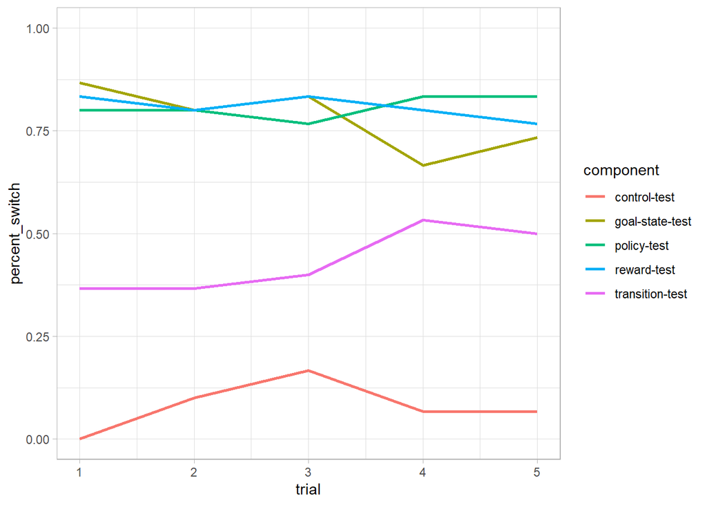

```r
# line plot state 1
ggplot(test_switch_component_trial_df, aes(x=trial, y=percent_switch, fill=component)) +
  geom_line(aes(color=component), size=1) +
  scale_y_continuous(limits = c(0, 1)) +
  theme_light() +
  scale_fill_manual(values=c('lightblue','#E69F00','seagreen','grey','pink'))
```

## Correct paths starting from state 1

- same pattern as when considering % correct in all states or in state 1 only

```r
test_correct_path_component_df <- trial_df %>%
  filter(phase == "test",
         state %in% c(1)
         ) %>%
  group_by(component) %>%
  summarise(mean_correct = mean(correct_path, na.rm = TRUE),
            se_correct = sd(correct_path, na.rm = TRUE)/sqrt(n()),
            ci_l = ci(correct_path, na.rm=TRUE)[2],
            ci_u = ci(correct_path, na.rm=TRUE)[3],
            n = n()
            )

test_correct_path_component_df %>%
  kable("html") %>%
  kable_styling(font_size = 18,
                latex_options = "scale_down")
```

| component | mean_correct | se_correct | ci_l | ci_u | n |
| --- | --- | --- | --- | --- | --- |
| control-test | 0.848 | 0.0227520 | 0.8031890 | 0.8928110 | 250 |
| goal-state-test | 0.660 | 0.0300201 | 0.6008744 | 0.7191256 | 250 |
| policy-test | 0.604 | 0.0309932 | 0.5429578 | 0.6650422 | 250 |
| reward-test | 0.652 | 0.0301866 | 0.5925464 | 0.7114536 | 250 |
| transition-test | 0.316 | 0.0294627 | 0.2579722 | 0.3740278 | 250 |

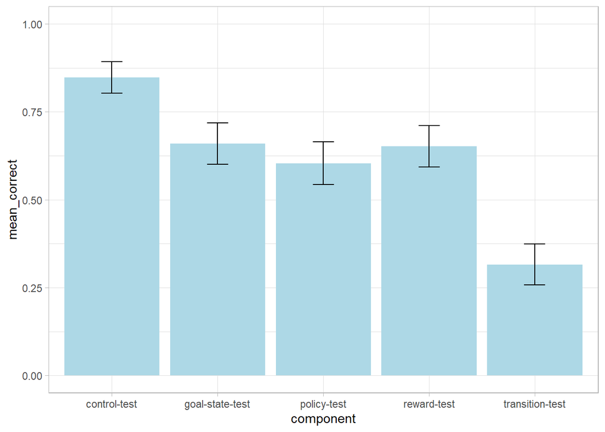

```r
# bar plot
ggplot(test_correct_path_component_df, aes(x=component, y=mean_correct)) +
  geom_bar(stat="identity", fill="lightblue") +
  geom_errorbar(aes(ymin=ci_l, ymax=ci_u), width=.2,
                position=position_dodge(.9)) +
  theme_light() +
  scale_y_continuous(limits = c(0, 1)) +
  theme_light()
```

## Rule out confounding variables / alternative explanations

### Switches per condition index

- switch rate intearcts unsystematically with condition index

```r
# get percent correct over time
test_switch_component_index_df <- df %>%
  mutate(condition_index = as.factor(condition_index)) %>%
  filter(phase == "test"
         ) %>%
  group_by(component, condition_index) %>%
  summarise(mean_switch = mean(switch, na.rm = TRUE),
            se_switch = sd(switch, na.rm = TRUE)/sqrt(n()),
            ci_l = ci(switch, na.rm=TRUE)[2],
            ci_u = ci(switch, na.rm=TRUE)[3],
            n = n()
            )

test_switch_component_index_df %>%
  kable("html") %>%
  kable_styling(font_size = 16,
                latex_options = "scale_down")
```

| component | condition_index | mean_switch | se_switch | ci_l | ci_u | n |
| --- | --- | --- | --- | --- | --- | --- |
| control-test | 1 | 0.0571429 | 0.0281481 | -0.0237556 | 0.1380413 | 70 |
| control-test | 2 | 0.1666667 | 0.0489350 | 0.0251274 | 0.3082059 | 60 |
| control-test | 3 | 0.0000000 | 0.0000000 | 0.0000000 | 0.0000000 | 20 |
| control-test | 4 | 0.1000000 | 0.0393919 | -0.0139369 | 0.2139369 | 60 |
| control-test | 5 | 0.0444444 | 0.0219682 | -0.0181686 | 0.1070575 | 90 |
| goal-state-test | 1 | 0.5333333 | 0.0655072 | 0.3438610 | 0.7228057 | 60 |
| goal-state-test | 2 | 1.0000000 | 0.0000000 | 1.0000000 | 1.0000000 | 20 |
| goal-state-test | 3 | 0.8333333 | 0.0489350 | 0.6917941 | 0.9748726 | 60 |
| goal-state-test | 4 | 0.8000000 | 0.0426401 | 0.6784688 | 0.9215312 | 90 |
| goal-state-test | 5 | 0.8571429 | 0.0424349 | 0.7351838 | 0.9791019 | 70 |
| policy-test | 1 | 0.8000000 | 0.0942809 | 0.4983790 | 1.1016210 | 20 |
| policy-test | 2 | 0.5666667 | 0.0650670 | 0.3784674 | 0.7548659 | 60 |
| policy-test | 3 | 0.8000000 | 0.0426401 | 0.6784688 | 0.9215312 | 90 |
| policy-test | 4 | 0.8571429 | 0.0424349 | 0.7351838 | 0.9791019 | 70 |
| policy-test | 5 | 1.0000000 | 0.0000000 | 1.0000000 | 1.0000000 | 60 |
| reward-test | 1 | 0.7111111 | 0.0483162 | 0.5734022 | 0.8488200 | 90 |
| reward-test | 2 | 0.6285714 | 0.0585950 | 0.4601678 | 0.7969751 | 70 |
| reward-test | 3 | 0.9333333 | 0.0327536 | 0.8385972 | 1.0280695 | 60 |
| reward-test | 4 | 1.0000000 | 0.0000000 | 1.0000000 | 1.0000000 | 20 |
| reward-test | 5 | 0.9666667 | 0.0235702 | 0.8984923 | 1.0348410 | 60 |
| transition-test | 1 | 0.3333333 | 0.0618984 | 0.1542988 | 0.5123679 | 60 |
| transition-test | 2 | 0.4888889 | 0.0532870 | 0.3370124 | 0.6407654 | 90 |
| transition-test | 3 | 0.2285714 | 0.0509219 | 0.0822206 | 0.3749223 | 70 |
| transition-test | 4 | 0.5333333 | 0.0655072 | 0.3438610 | 0.7228057 | 60 |
| transition-test | 5 | 0.9000000 | 0.0707107 | 0.6737843 | 1.1262157 | 20 |

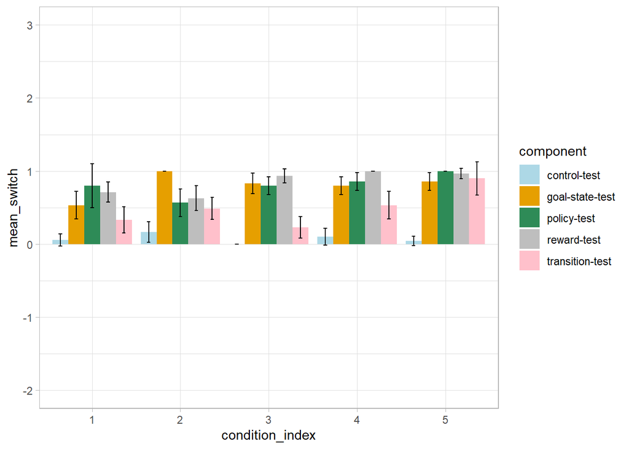

```r
# bar plot
ggplot(test_switch_component_index_df, aes(x=condition_index, y=mean_switch, fill=component)) +
  geom_bar(stat="identity", position=position_dodge()) +
  geom_errorbar(aes(ymin=ci_l, ymax=ci_u), width=.2, position=position_dodge(.9)) +
  scale_y_continuous(limits = c(-2, 3)) +
  theme_light() +
  scale_fill_manual(values=c('lightblue','#E69F00','seagreen','grey','pink'))
```

### Time on task * condition (changes in strategy over time)

- condition effects on switch rate interact with time on task –> changes in strategy over time
- but relatively low n per condition order

#### LogReg: Switches per accumulated state visits on task * difference from control

```r
logreg_test_switch_condition_accumulatedtrial_df <- df %>%
  filter(phase == "test") %>%
  mutate(switch = as.factor(switch),
         condition = as.factor(condition)) %>%
  select(ID,
         switch,
         condition,
         accumulated_states_visited)

contrasts(logreg_test_switch_condition_accumulatedtrial_df$condition) <- contr.treatment(5, base = 1)

log_model_accumulated_states_visited_control <- glm(switch ~ 1 + accumulated_states_visited*condition, data = logreg_test_switch_condition_accumulatedtrial_df, family = "binomial")

tab_model(log_model_accumulated_states_visited_control, transform = NULL, show.est = T, show.stat = T, auto.label = FALSE, CSS = list(css.table = '+font-size: 10;'))
```

|  | switch |  |  |  |
| --- | --- | --- | --- | --- |
| Predictors | Log-Odds | CI | Statistic | p |
| (Intercept) | -2.07 | -3.41 – -0.95 | -3.35 | **0.001** |
| accumulated_states_visited | -0.00 | -0.00 – 0.00 | -0.66 | 0.506 |
| condition2 | 2.24 | 0.81 – 3.83 | 2.94 | **0.003** |
| condition3 | 1.47 | -0.15 – 3.21 | 1.73 | 0.083 |
| condition4 | 2.00 | 0.58 – 3.56 | 2.65 | **0.008** |
| condition5 | 0.99 | -0.41 – 2.53 | 1.33 | 0.182 |
| accumulated_states_visited:condition2 | 0.00 | 0.00 – 0.01 | 2.04 | **0.041** |
| accumulated_states_visited:condition3 | 0.01 | 0.00 – 0.01 | 2.93 | **0.003** |
| accumulated_states_visited:condition4 | 0.01 | 0.00 – 0.01 | 2.93 | **0.003** |
| accumulated_states_visited:condition5 | 0.00 | -0.00 – 0.01 | 1.83 | 0.067 |
| Observations | 750 |  |  |  |
| R<sup>2</sup> Tjur | 0.376 |  |  |  |

#### LogReg: Switches per accumulated state visits on task * difference from goal-state

```r
contrasts(logreg_test_switch_condition_accumulatedtrial_df$condition) <- contr.treatment(5, base = 2)

log_model_accumulated_states_visited_goalstate <- glm(switch ~ 1 + accumulated_states_visited*condition, data = logreg_test_switch_condition_accumulatedtrial_df, family = "binomial")
tab_model(log_model_accumulated_states_visited_goalstate, transform = NULL, show.est = T, show.stat = T, auto.label = FALSE, CSS = list(css.table = '+font-size: 10;'))
```

|  | switch |  |  |  |
| --- | --- | --- | --- | --- |
| Predictors | Log-Odds | CI | Statistic | p |
| (Intercept) | 0.18 | -0.69 – 1.08 | 0.39 | 0.693 |
| accumulated_states_visited | 0.00 | 0.00 – 0.00 | 2.55 | **0.011** |
| condition1 | -2.24 | -3.83 – -0.81 | -2.94 | **0.003** |
| condition3 | -0.77 | -2.23 – 0.67 | -1.05 | 0.295 |
| condition4 | -0.25 | -1.48 – 0.96 | -0.40 | 0.690 |
| condition5 | -1.25 | -2.47 – -0.08 | -2.06 | **0.039** |
| accumulated_states_visited:condition1 | -0.00 | -0.01 – -0.00 | -2.04 | **0.041** |
| accumulated_states_visited:condition3 | 0.00 | -0.00 – 0.01 | 1.33 | 0.182 |
| accumulated_states_visited:condition4 | 0.00 | -0.00 – 0.01 | 1.36 | 0.175 |
| accumulated_states_visited:condition5 | -0.00 | -0.00 – 0.00 | -0.23 | 0.816 |
| Observations | 750 |  |  |  |
| R<sup>2</sup> Tjur | 0.376 |  |  |  |

#### LogReg: Switches per accumulated state visits on task * difference from policy

```r
contrasts(logreg_test_switch_condition_accumulatedtrial_df$condition) <- contr.treatment(5, base = 3)

log_model_accumulated_states_visited_reward <- glm(switch ~ 1 + accumulated_states_visited*condition, data = logreg_test_switch_condition_accumulatedtrial_df, family = "binomial")
tab_model(log_model_accumulated_states_visited_reward, transform = NULL, show.est = T, show.stat = T, auto.label = FALSE, CSS = list(css.table = '+font-size: 10;'))
```

|  | switch |  |  |  |
| --- | --- | --- | --- | --- |
| Predictors | Log-Odds | CI | Statistic | p |
| (Intercept) | -0.59 | -1.76 – 0.55 | -1.02 | 0.309 |
| accumulated_states_visited | 0.00 | 0.00 – 0.01 | 3.42 | **0.001** |
| condition1 | -1.47 | -3.21 – 0.15 | -1.73 | 0.083 |
| condition2 | 0.77 | -0.67 – 2.23 | 1.05 | 0.295 |
| condition4 | 0.52 | -0.90 – 1.95 | 0.72 | 0.470 |
| condition5 | -0.48 | -1.89 – 0.92 | -0.68 | 0.499 |
| accumulated_states_visited:condition1 | -0.01 | -0.01 – -0.00 | -2.93 | **0.003** |
| accumulated_states_visited:condition2 | -0.00 | -0.01 – 0.00 | -1.33 | 0.182 |
| accumulated_states_visited:condition4 | 0.00 | -0.00 – 0.00 | 0.03 | 0.972 |
| accumulated_states_visited:condition5 | -0.00 | -0.01 – 0.00 | -1.52 | 0.129 |
| Observations | 750 |  |  |  |
| R<sup>2</sup> Tjur | 0.376 |  |  |  |

#### LogReg: Switches per accumulated state visits on task * difference from reward

```r
contrasts(logreg_test_switch_condition_accumulatedtrial_df$condition) <- contr.treatment(5, base = 4)

log_model_accumulated_states_visited_transition <- glm(switch ~ 1 + accumulated_states_visited*condition, data = logreg_test_switch_condition_accumulatedtrial_df, family = "binomial")
tab_model(log_model_accumulated_states_visited_transition, transform = NULL, show.est = T, show.stat = T, auto.label = FALSE, CSS = list(css.table = '+font-size: 10;'))
```

|  | switch |  |  |  |
| --- | --- | --- | --- | --- |
| Predictors | Log-Odds | CI | Statistic | p |
| (Intercept) | -0.07 | -0.93 – 0.77 | -0.16 | 0.869 |
| accumulated_states_visited | 0.00 | 0.00 – 0.01 | 3.40 | **0.001** |
| condition1 | -2.00 | -3.56 – -0.58 | -2.65 | **0.008** |
| condition2 | 0.25 | -0.96 – 1.48 | 0.40 | 0.690 |
| condition3 | -0.52 | -1.95 – 0.90 | -0.72 | 0.470 |
| condition5 | -1.01 | -2.18 – 0.16 | -1.69 | 0.090 |
| accumulated_states_visited:condition1 | -0.01 | -0.01 – -0.00 | -2.93 | **0.003** |
| accumulated_states_visited:condition2 | -0.00 | -0.01 – 0.00 | -1.36 | 0.175 |
| accumulated_states_visited:condition3 | -0.00 | -0.00 – 0.00 | -0.03 | 0.972 |
| accumulated_states_visited:condition5 | -0.00 | -0.01 – 0.00 | -1.54 | 0.125 |
| Observations | 750 |  |  |  |
| R<sup>2</sup> Tjur | 0.376 |  |  |  |

#### LogReg: Switches per accumulated state visits on task * difference from transition

```r
contrasts(logreg_test_switch_condition_accumulatedtrial_df$condition) <- contr.treatment(5, base = 5)

log_model_accumulated_states_visited_transition <- glm(switch ~ 1 + accumulated_states_visited*condition, data = logreg_test_switch_condition_accumulatedtrial_df, family = "binomial")
tab_model(log_model_accumulated_states_visited_transition, transform = NULL, show.est = T, show.stat = T, auto.label = FALSE, CSS = list(css.table = '+font-size: 10;'))
```

|  | switch |  |  |  |
| --- | --- | --- | --- | --- |
| Predictors | Log-Odds | CI | Statistic | p |
| (Intercept) | -1.08 | -1.90 – -0.29 | -2.62 | **0.009** |
| accumulated_states_visited | 0.00 | 0.00 – 0.00 | 2.17 | **0.030** |
| condition1 | -0.99 | -2.53 – 0.41 | -1.33 | 0.182 |
| condition2 | 1.25 | 0.08 – 2.47 | 2.06 | **0.039** |
| condition3 | 0.48 | -0.92 – 1.89 | 0.68 | 0.499 |
| condition4 | 1.01 | -0.16 – 2.18 | 1.69 | 0.090 |
| accumulated_states_visited:condition1 | -0.00 | -0.01 – 0.00 | -1.83 | 0.067 |
| accumulated_states_visited:condition2 | 0.00 | -0.00 – 0.00 | 0.23 | 0.816 |
| accumulated_states_visited:condition3 | 0.00 | -0.00 – 0.01 | 1.52 | 0.129 |
| accumulated_states_visited:condition4 | 0.00 | -0.00 – 0.01 | 1.54 | 0.125 |
| Observations | 750 |  |  |  |
| R<sup>2</sup> Tjur | 0.376 |  |  |  |

### Switches per environment

- no systematic effects of environment

```r
# get percent correct over time
test_switch_component_environment_df <- df %>%
  mutate(environment = as.factor(environment)) %>%
  filter(phase == "test"
         ) %>%
  group_by(component, environment) %>%
  summarise(mean_switch = mean(switch, na.rm = TRUE),
            se_switch = sd(switch, na.rm = TRUE)/sqrt(n()),
            ci_l = ci(switch, na.rm=TRUE)[2],
            ci_u = ci(switch, na.rm=TRUE)[3],
            n = n())

test_switch_component_environment_df %>%
  kable("html") %>%
  kable_styling(font_size = 16,
                latex_options = "scale_down")
```

| component | environment | mean_switch | se_switch | ci_l | ci_u | n |
| --- | --- | --- | --- | --- | --- | --- |
| control-test | blue_floral | 0.1200000 | 0.0469042 | -0.0169035 | 0.2569035 | 50 |
| control-test | messy_green | 0.0285714 | 0.0202031 | -0.0294927 | 0.0866356 | 70 |
| control-test | orange_tile | 0.0500000 | 0.0246774 | -0.0205901 | 0.1205901 | 80 |
| control-test | red_brown | 0.0000000 | 0.0000000 | 0.0000000 | 0.0000000 | 40 |
| control-test | white_modern | 0.2000000 | 0.0525226 | 0.0480842 | 0.3519158 | 60 |
| goal-state-test | blue_floral | 0.9714286 | 0.0202031 | 0.9133644 | 1.0294927 | 70 |
| goal-state-test | messy_green | 0.7750000 | 0.0472819 | 0.6397494 | 0.9102506 | 80 |
| goal-state-test | orange_tile | 0.8000000 | 0.0648886 | 0.6079309 | 0.9920691 | 40 |
| goal-state-test | red_brown | 0.8666667 | 0.0446356 | 0.7375630 | 0.9957703 | 60 |
| goal-state-test | white_modern | 0.4000000 | 0.0707107 | 0.1936101 | 0.6063899 | 50 |
| policy-test | blue_floral | 0.7250000 | 0.0505578 | 0.5803786 | 0.8696214 | 80 |
| policy-test | messy_green | 1.0000000 | 0.0000000 | 1.0000000 | 1.0000000 | 40 |
| policy-test | orange_tile | 0.7666667 | 0.0555364 | 0.6060337 | 0.9272997 | 60 |
| policy-test | red_brown | 0.8000000 | 0.0577350 | 0.6314834 | 0.9685166 | 50 |
| policy-test | white_modern | 0.8285714 | 0.0457038 | 0.6972175 | 0.9599254 | 70 |
| reward-test | blue_floral | 0.7000000 | 0.0601722 | 0.5259585 | 0.8740415 | 60 |
| reward-test | messy_green | 0.9600000 | 0.0282843 | 0.8774441 | 1.0425559 | 50 |
| reward-test | orange_tile | 0.8000000 | 0.0485071 | 0.6605892 | 0.9394108 | 70 |
| reward-test | red_brown | 0.8250000 | 0.0430228 | 0.7019325 | 0.9480675 | 80 |
| reward-test | white_modern | 0.7500000 | 0.0702439 | 0.5420791 | 0.9579209 | 40 |
| transition-test | blue_floral | 0.5000000 | 0.0811107 | 0.2599137 | 0.7400863 | 40 |
| transition-test | messy_green | 0.2666667 | 0.0580659 | 0.0987174 | 0.4346160 | 60 |
| transition-test | orange_tile | 0.4000000 | 0.0707107 | 0.1936101 | 0.6063899 | 50 |
| transition-test | red_brown | 0.3428571 | 0.0575615 | 0.1774238 | 0.5082905 | 70 |
| transition-test | white_modern | 0.6250000 | 0.0548161 | 0.4681975 | 0.7818025 | 80 |

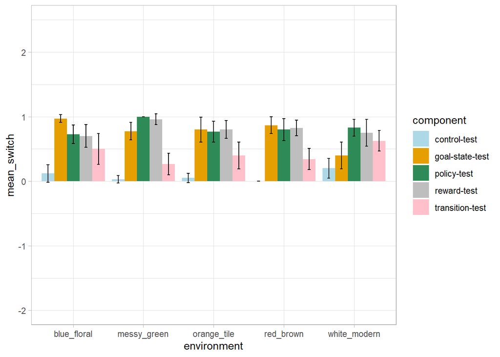

```r
# bar plot
ggplot(test_switch_component_environment_df, aes(x=environment, y=mean_switch, fill=component)) +
  geom_bar(stat="identity", position=position_dodge()) +
  geom_errorbar(aes(ymin=ci_l, ymax=ci_u), width=.2, position=position_dodge(.9)) +
  scale_y_continuous(limits = c(-2, 2.5)) +
  theme_light() +
  scale_fill_manual(values=c('lightblue','#E69F00','seagreen','grey','pink'))
```

# Rating phase

- rating diff = optimal state 1 action rating - suboptimal state 1 action rating
- reflects same pattern as test trials
- negative score for transition revaluation: suboptimal action rated better than optimal action

## Rating difference optimal - suboptimal action state 1

```r
rating_state1_component_df <- rating_df %>%
  filter(state == 1) %>%
  group_by(component) %>%
  summarise(n = n(),
            mean_rating_diff = mean(rating_diff_state1, na.rm=T),
            se_rating_diff = sd(rating_diff_state1, na.rm = TRUE)/sqrt(n()),
            ci_l = ci(rating_diff_state1, na.rm=TRUE)[2],
            ci_u = ci(rating_diff_state1, na.rm=TRUE)[3]
            )

rating_state1_component_df %>%
  kable("html") %>%
  kable_styling(font_size = 18,
                latex_options = "scale_down")
```

| component | n | mean_rating_diff | se_rating_diff | ci_l | ci_u |
| --- | --- | --- | --- | --- | --- |
| control-rating | 100 | 42.14 | 3.160277 | 33.1585920 | 51.121408 |
| goal-state-rating | 100 | 14.28 | 4.229394 | 2.2601960 | 26.299804 |
| policy-rating | 100 | 9.92 | 3.372387 | 0.3357814 | 19.504219 |
| reward-rating | 100 | 16.72 | 2.845479 | 8.6332380 | 24.806762 |
| transition-rating | 100 | -18.04 | 4.118944 | -29.7459087 | -6.334091 |

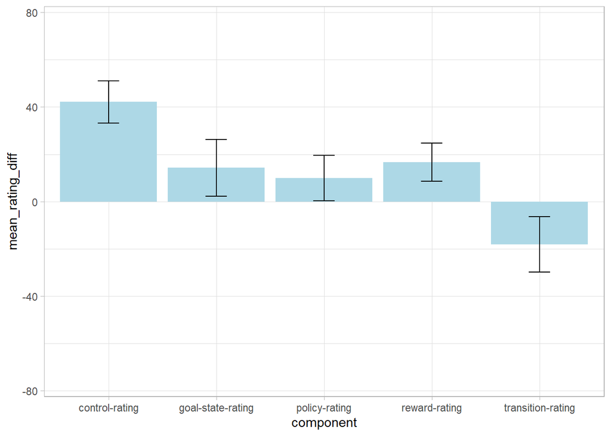

```r
# bar plot
ggplot(rating_state1_component_df, aes(x=component, y=mean_rating_diff)) +
  geom_bar(stat="identity", fill="lightblue") +
  geom_errorbar(aes(ymin=ci_l, ymax=ci_u), width=.2, position=position_dodge(.9)) +
  scale_y_continuous(limits = c(-75, 75)) +
  theme_light()
```

### Relation to test choices

- rating difference related to test choices

```r
test_state1_df <- df %>%
  filter(phase == "test",
         state == 1) %>%
  group_by(ID, condition) %>%
  summarise(percent_correct = mean(correct))

rating_diff_state1_df <- rating_df %>%
  filter(state == 1) %>%
  group_by(ID, condition) %>%
  summarise(rating_diff = sum(rating_diff, na.rm=T))

test_rating_state1_df <- merge(test_state1_df, rating_diff_state1_df, by = c("ID", "condition"))
```

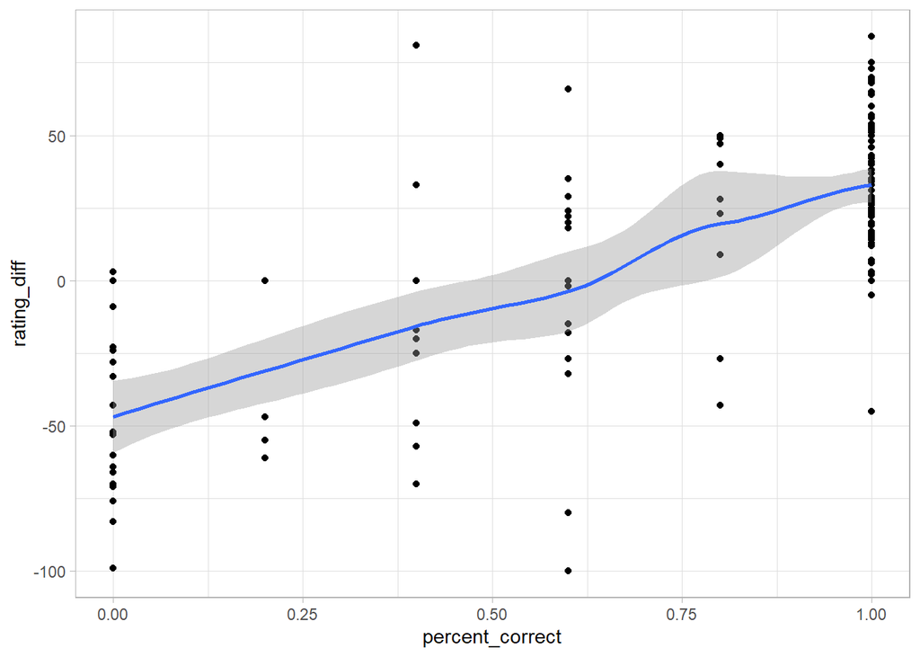

```r
# scatter plot
ggplot(test_rating_state1_df, aes(x=percent_correct, y=rating_diff)) +
  geom_point() +
  geom_smooth() +
  theme_light()
```

## Rating difference optimal - suboptimal action state 2

```r
rating_state2_component_df <- rating_df %>%
  filter(state == 2) %>%
  group_by(component) %>%
  summarise(n = n(),
            mean_rating_diff = mean(rating_diff_state2, na.rm=T),
            se_rating_diff = sd(rating_diff_state2, na.rm = TRUE)/sqrt(n()),
            ci_l = ci(rating_diff_state2, na.rm=TRUE)[2],
            ci_u = ci(rating_diff_state2, na.rm=TRUE)[3]
            )

rating_state2_component_df %>%
  kable("html") %>%
  kable_styling(font_size = 18,
                latex_options = "scale_down")
```

| component | n | mean_rating_diff | se_rating_diff | ci_l | ci_u |
| --- | --- | --- | --- | --- | --- |
| control-rating | 100 | 29.18 | 5.245122 | 14.27353 | 44.08647 |
| goal-state-rating | 100 | 34.90 | 5.820066 | 18.35956 | 51.44044 |
| policy-rating | 100 | 23.54 | 4.335295 | 11.21923 | 35.86077 |
| reward-rating | 100 | 45.16 | 6.083680 | 27.87037 | 62.44963 |
| transition-rating | 100 | 2.96 | 5.310981 | -12.13364 | 18.05364 |

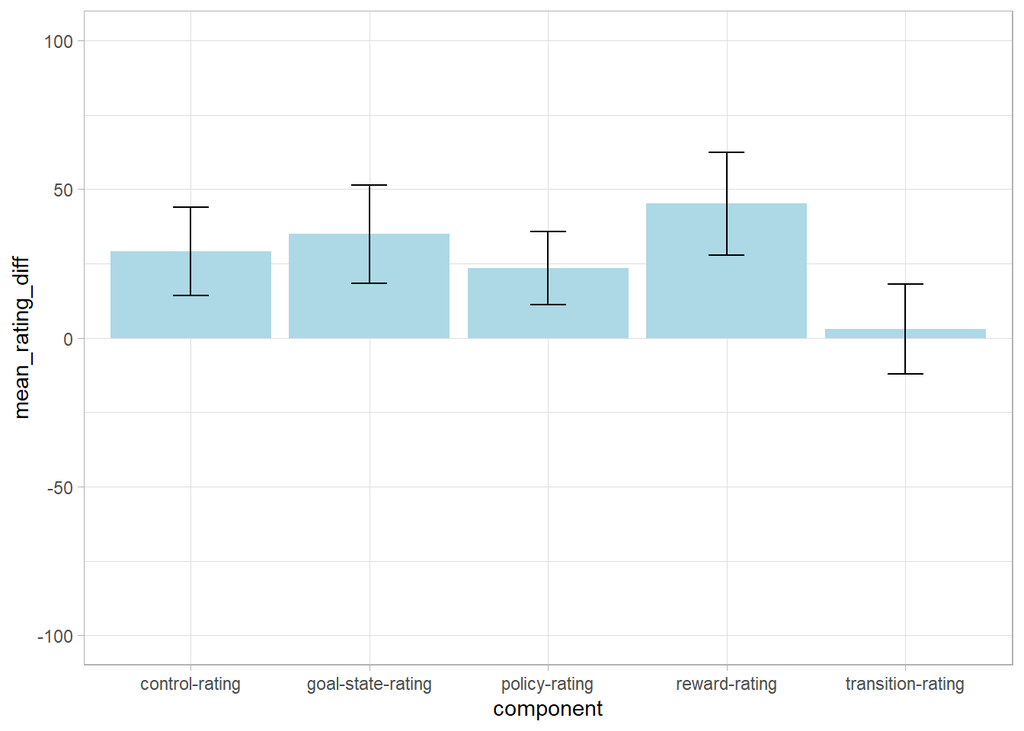

```r
# bar plot
ggplot(rating_state2_component_df, aes(x=component, y=mean_rating_diff)) +
  geom_bar(stat="identity", fill="lightblue") +
  geom_errorbar(aes(ymin=ci_l, ymax=ci_u), width=.2, position=position_dodge(.9)) +
  scale_y_continuous(limits = c(-100, 100)) +
  theme_light()
```

### Relation to test choices

```r
test_state2_df <- df %>%
  filter(phase == "test",
         state == 2) %>%
  group_by(ID, condition) %>%
  summarise(percent_correct = mean(correct))

rating_diff_state2_df <- rating_df %>%
  filter(state == 2) %>%
  group_by(ID, condition) %>%
  summarise(rating_diff = sum(rating_diff, na.rm=T))

test_rating_state2_df <- merge(test_state2_df, rating_diff_state2_df, by = c("ID", "condition"))
```

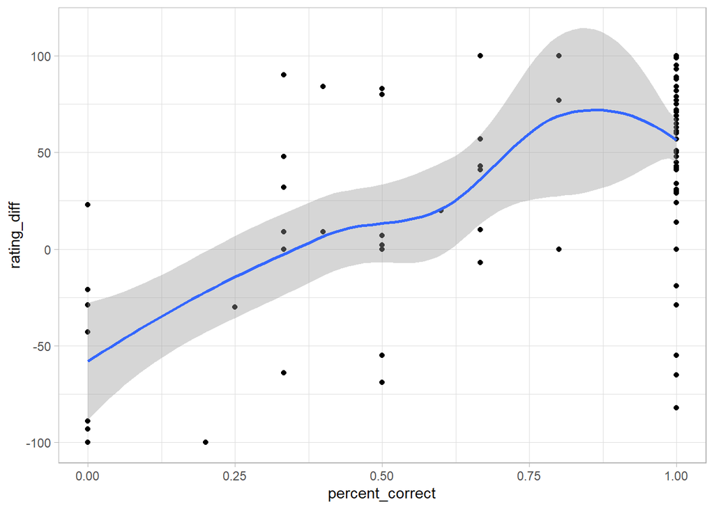

```r
# scatter plot
ggplot(test_rating_state2_df, aes(x=percent_correct, y=rating_diff)) +
  geom_point() +
  geom_smooth() +
  theme_light()
```

## Rating difference optimal - suboptimal action state 3

```r
rating_state3_component_df <- rating_df %>%
  filter(state == 3) %>%
  group_by(component) %>%
  summarise(n = n(),
            mean_rating_diff = mean(rating_diff_state3, na.rm=T),
            se_rating_diff = sd(rating_diff_state3, na.rm = TRUE)/sqrt(n()),
            ci_l = ci(rating_diff_state3, na.rm=TRUE)[2],
            ci_u = ci(rating_diff_state3, na.rm=TRUE)[3]
            )

rating_state3_component_df %>%
  kable("html") %>%
  kable_styling(font_size = 18,
                latex_options = "scale_down")
```

| component | n | mean_rating_diff | se_rating_diff | ci_l | ci_u |
| --- | --- | --- | --- | --- | --- |
| control-rating | 100 | 55.62 | 4.948712 | 41.555916 | 69.68408 |
| goal-state-rating | 100 | 44.28 | 5.150710 | 29.641845 | 58.91816 |
| policy-rating | 100 | 21.70 | 3.674193 | 11.258059 | 32.14194 |
| reward-rating | 100 | 56.14 | 4.258102 | 44.038608 | 68.24139 |
| transition-rating | 100 | 23.42 | 4.798941 | 9.781561 | 37.05844 |

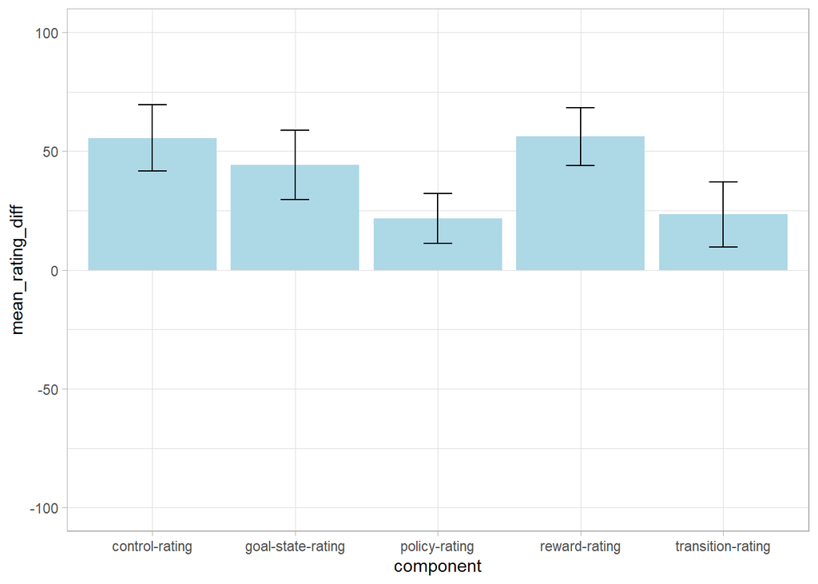

```r
# bar plot
ggplot(rating_state3_component_df, aes(x=component, y=mean_rating_diff)) +
  geom_bar(stat="identity", fill="lightblue") +
  geom_errorbar(aes(ymin=ci_l, ymax=ci_u), width=.2, position=position_dodge(.9)) +
  scale_y_continuous(limits = c(-100, 100)) +
  theme_light()
```

### Relation to test choices

```r
test_state3_df <- df %>%
  filter(phase == "test",
         state == 3) %>%
  group_by(ID, condition) %>%
  summarise(percent_correct = mean(correct))

rating_diff_state3_df <- rating_df %>%
  filter(state == 3) %>%
  group_by(ID, condition) %>%
  summarise(rating_diff = sum(rating_diff, na.rm=T))

test_rating_state3_df <- merge(test_state3_df, rating_diff_state3_df, by = c("ID", "condition"))
```

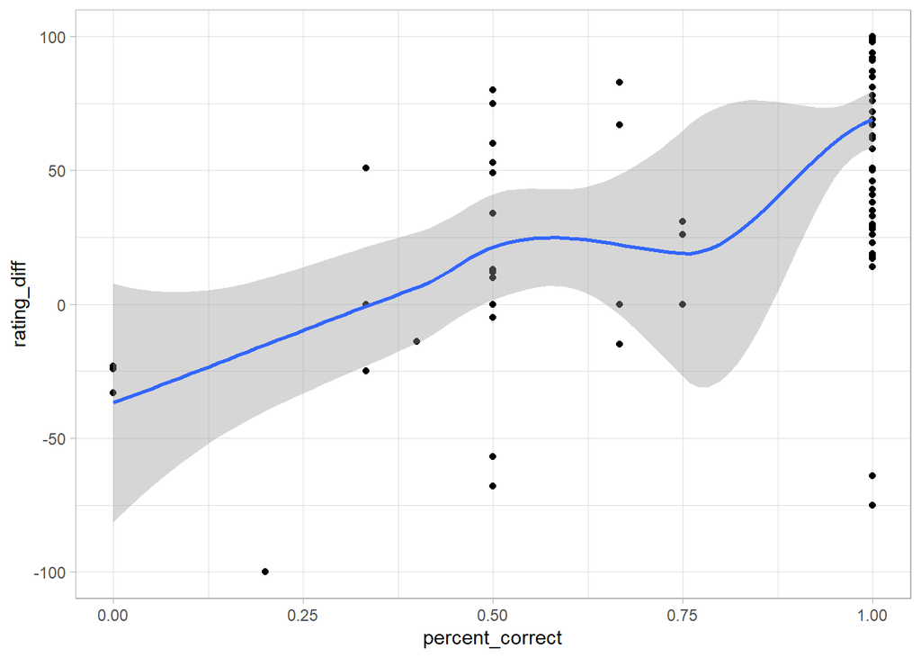

```r
# scatter plot
ggplot(test_rating_state3_df, aes(x=percent_correct, y=rating_diff)) +
  geom_point() +
  geom_smooth() +
  theme_light()
```

# Reaction times

## RT per condition and phase

```r
RT_condition_phase_df <- df %>%
  filter(component %in% c("control-learning",
                          "control-relearning",
                          "control-test",
                          "reward-learning",
                          "reward-relearning",
                          "reward-test",
                          "transition-learning",
                          "transition-relearning",
                          "transition-test",
                          "policy-learning",
                          "policy-relearning",
                          "policy-test",
                          "goal-state-learning",
                          "goal-state-relearning",
                          "goal-state-test")) %>%
  group_by(condition, phase) %>%
  summarise(mean_RT = mean(RT),
            se_RT = sd(RT, na.rm = TRUE)/sqrt(n()),
            ci_l = ci(RT, na.rm=TRUE)[2],
            ci_u = ci(RT, na.rm=TRUE)[3])

RT_condition_phase_df %>%
  kable("html") %>%
  kable_styling(font_size = 16,
                latex_options = "scale_down")
```

| condition | phase | mean_RT | se_RT | ci_l | ci_u |
| --- | --- | --- | --- | --- | --- |
| control | learning | 482.3056 | 5.651259 | 471.2256 | 493.3856 |
| control | relearning | 391.4679 | 8.580552 | 374.6253 | 408.3106 |
| control | test | 484.0317 | 42.985898 | 399.4384 | 568.6249 |
| goal-state | learning | 466.0973 | 5.147943 | 456.0041 | 476.1905 |
| goal-state | relearning | 436.3967 | 10.498611 | 415.7896 | 457.0039 |
| goal-state | test | 565.6203 | 48.672793 | 469.8357 | 661.4050 |
| policy | learning | 448.5290 | 5.126807 | 438.4773 | 458.5808 |
| policy | relearning | 428.5234 | 9.489494 | 409.8965 | 447.1503 |
| policy | test | 500.7307 | 35.011541 | 431.8304 | 569.6309 |
| reward | learning | 448.8806 | 5.245677 | 438.5958 | 459.1654 |
| reward | relearning | 423.0160 | 10.489911 | 402.4254 | 443.6066 |
| reward | test | 540.7277 | 37.267688 | 467.3875 | 614.0679 |
| transition | learning | 444.3407 | 4.932623 | 434.6697 | 454.0117 |
| transition | relearning | 426.1380 | 9.712253 | 407.0739 | 445.2021 |
| transition | test | 512.3327 | 42.161926 | 429.3610 | 595.3044 |

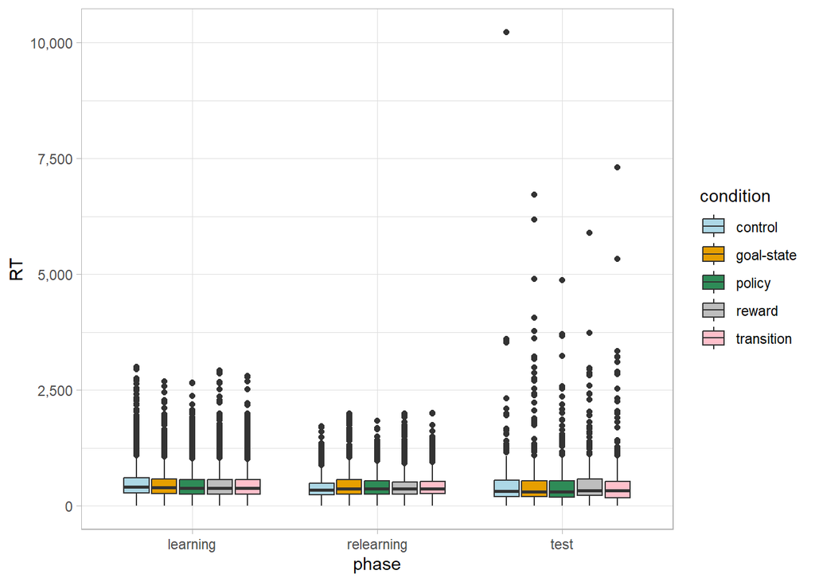

```r
ggplot(df, aes(x=phase, y=RT, fill = condition)) +
  geom_boxplot() +
  scale_y_continuous(labels = scales::comma) +
  theme_light() +
  scale_fill_manual(values=c('lightblue','#E69F00','seagreen','grey','pink'))
```

## 2-choice states

### RT in 2-choice states per condition and phase

```r
twochoice_RT_condition_phase_df <- df %>%
  filter(component %in% c("control-learning",
                          "control-test",
                          "reward-learning",
                          "reward-test",
                          "transition-learning",
                          "transition-test",
                          "policy-learning",
                          "policy-test",
                          "goal-state-learning",
                          "goal-state-test"),
         state %in% c(1,2,3)) %>%
  group_by(condition, phase) %>%
  summarise(mean_RT = mean(RT),
            se_RT = sd(RT, na.rm = TRUE)/sqrt(n()),
            ci_l = ci(RT, na.rm=TRUE)[2],
            ci_u = ci(RT, na.rm=TRUE)[3])

twochoice_RT_condition_phase_df %>%
  kable("html") %>%
  kable_styling(font_size = 16,
                latex_options = "scale_down")
```

| condition | phase | mean_RT | se_RT | ci_l | ci_u |
| --- | --- | --- | --- | --- | --- |
| control | learning | 435.7675 | 13.59808 | 409.0708 | 462.4642 |
| control | test | 484.0317 | 42.98590 | 399.4384 | 568.6249 |
| goal-state | learning | 387.1050 | 10.54304 | 366.4062 | 407.8038 |
| goal-state | test | 565.6203 | 48.67279 | 469.8357 | 661.4050 |
| policy | learning | 390.1508 | 11.55799 | 367.4594 | 412.8423 |
| policy | test | 500.7307 | 35.01154 | 431.8304 | 569.6309 |
| reward | learning | 380.3743 | 11.78354 | 357.2401 | 403.5086 |
| reward | test | 540.7277 | 37.26769 | 467.3875 | 614.0679 |
| transition | learning | 376.2781 | 11.12037 | 354.4458 | 398.1103 |
| transition | test | 512.3327 | 42.16193 | 429.3610 | 595.3044 |

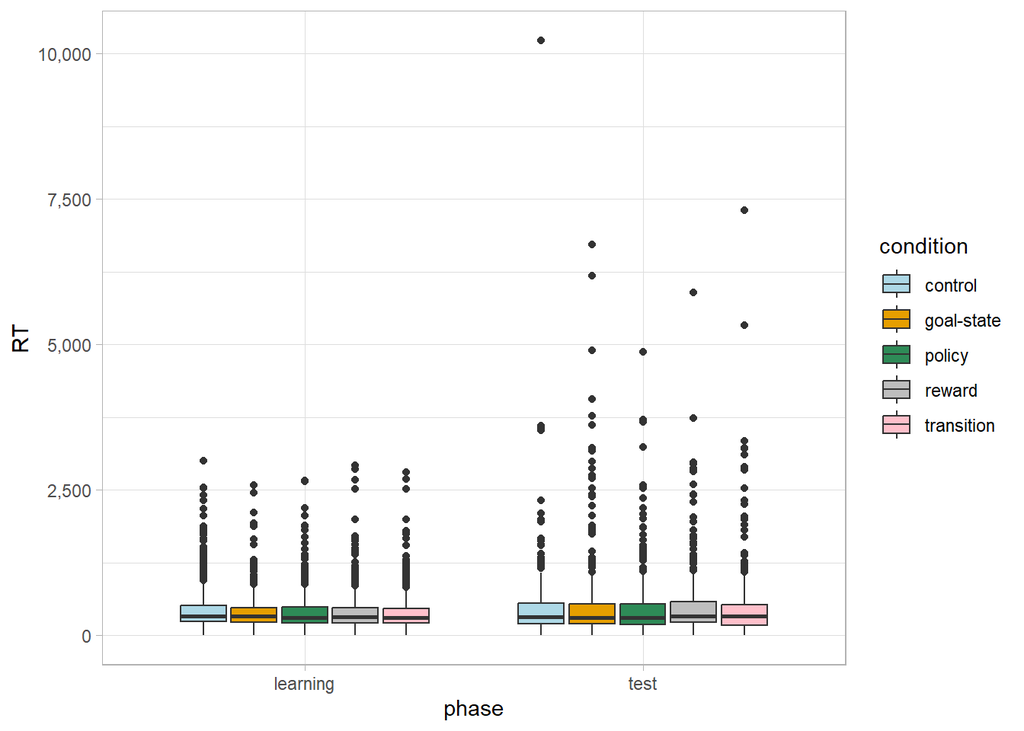

```r
twochoice_RT_df <- df %>%
  filter(component %in% c("control-learning",
                          "control-test",
                          "reward-learning",
                          "reward-test",
                          "transition-learning",
                          "transition-test",
                          "policy-learning",
                          "policy-test",
                          "goal-state-learning",
                          "goal-state-test"),
         state %in% c(1,2,3))

ggplot(twochoice_RT_df, aes(x=phase, y=RT, fill = condition)) +
  geom_boxplot() +
  scale_y_continuous(labels = scales::comma) +
  theme_light() +
  scale_fill_manual(values=c('lightblue','#E69F00','seagreen','grey','pink'))
```

### RT in state 1 per condition and phase

```r
state1_RT_condition_phase_df <- df %>%
  filter(component %in% c("control-learning",
                          "control-test",
                          "reward-learning",
                          "reward-test",
                          "transition-learning",
                          "transition-test",
                          "policy-learning",
                          "policy-test",
                          "goal-state-learning",
                          "goal-state-test"),
         state %in% c(1)) %>%
  group_by(condition, phase) %>%
  summarise(mean_RT = mean(RT),
            se_RT = sd(RT, na.rm = TRUE)/sqrt(n()),
            ci_l = ci(RT, na.rm=TRUE)[2],
            ci_u = ci(RT, na.rm=TRUE)[3])

state1_RT_condition_phase_df %>%
  kable("html") %>%
  kable_styling(font_size = 16,
                latex_options = "scale_down")
```

| condition | phase | mean_RT | se_RT | ci_l | ci_u |
| --- | --- | --- | --- | --- | --- |
| control | learning | 479.2331 | 22.15399 | 435.6652 | 522.8010 |
| control | test | 563.5787 | 75.47828 | 414.4326 | 712.7247 |
| goal-state | learning | 416.7453 | 16.21312 | 384.8606 | 448.6299 |
| goal-state | test | 596.1973 | 60.84211 | 475.9725 | 716.4222 |
| policy | learning | 416.5064 | 16.84600 | 383.3771 | 449.6356 |
| policy | test | 615.9980 | 62.18995 | 493.1098 | 738.8862 |
| reward | learning | 419.8489 | 19.95373 | 380.6080 | 459.0898 |
| reward | test | 679.9260 | 66.59920 | 548.3251 | 811.5269 |
| transition | learning | 415.8117 | 17.11173 | 382.1598 | 449.4635 |
| transition | test | 601.7033 | 71.24731 | 460.9177 | 742.4890 |

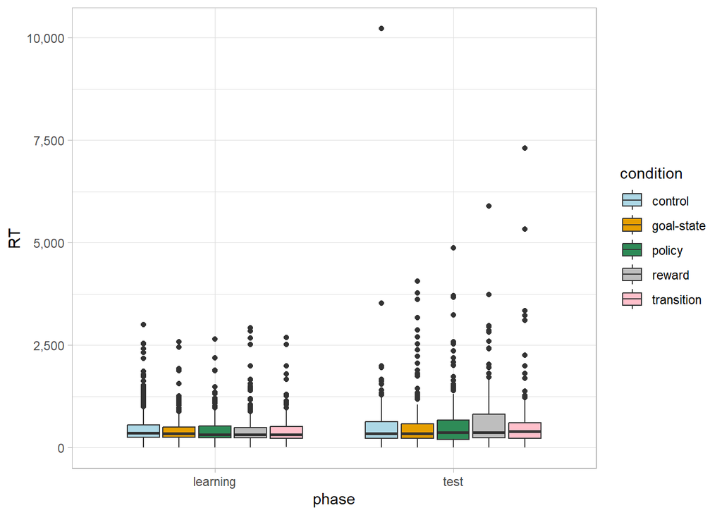

```r
state1_RT_df <- df %>%
  filter(component %in% c("control-learning",
                          "control-test",
                          "reward-learning",
                          "reward-test",
                          "transition-learning",
                          "transition-test",
                          "policy-learning",
                          "policy-test",
                          "goal-state-learning",
                          "goal-state-test"),
         state %in% c(1))

ggplot(state1_RT_df, aes(x=phase, y=RT, fill = condition)) +
  geom_boxplot() +
  scale_y_continuous(labels = scales::comma) +
  theme_light() +
  scale_fill_manual(values=c('lightblue','#E69F00','seagreen','grey','pink'))
```

### Relation RT - correct

- higher RT in incorrect trials

#### Learning RT in 2-choice states - correct choice

```r
learning_twochoice_RT_condition_phase_correct_df <- df %>%
  filter(component %in% c("control-learning",
                          "reward-learning",
                          "transition-learning",
                          "goal-state-learning"),
         state %in% c(1,2,3)) %>%
  group_by(condition, phase, correct) %>%
  summarise(mean_RT = mean(RT),
            se_RT = sd(RT, na.rm = TRUE)/sqrt(n()),
            ci_l = ci(RT, na.rm=TRUE)[2],
            ci_u = ci(RT, na.rm=TRUE)[3],
            n = n())

learning_twochoice_RT_condition_phase_correct_df %>%
  kable("html") %>%
  kable_styling(font_size = 16,
                latex_options = "scale_down")
```

| condition | phase | correct | mean_RT | se_RT | ci_l | ci_u | n |
| --- | --- | --- | --- | --- | --- | --- | --- |
| control | learning | 0 | 698.5538 | 107.56449 | 477.0206 | 920.0871 | 26 |
| control | learning | 1 | 425.9225 | 13.39859 | 399.6158 | 452.2292 | 694 |
| goal-state | learning | 0 | 484.6500 | 120.13807 | 212.8788 | 756.4212 | 10 |
| goal-state | learning | 1 | 385.7311 | 10.56120 | 364.9962 | 406.4661 | 710 |
| reward | learning | 0 | 916.0917 | 194.84978 | 487.2302 | 1344.9531 | 12 |
| reward | learning | 1 | 371.2944 | 11.25136 | 349.2043 | 393.3844 | 708 |
| transition | learning | 0 | 458.6250 | 109.91972 | 198.7062 | 718.5438 | 8 |
| transition | learning | 1 | 375.3528 | 11.18097 | 353.4011 | 397.3045 | 712 |

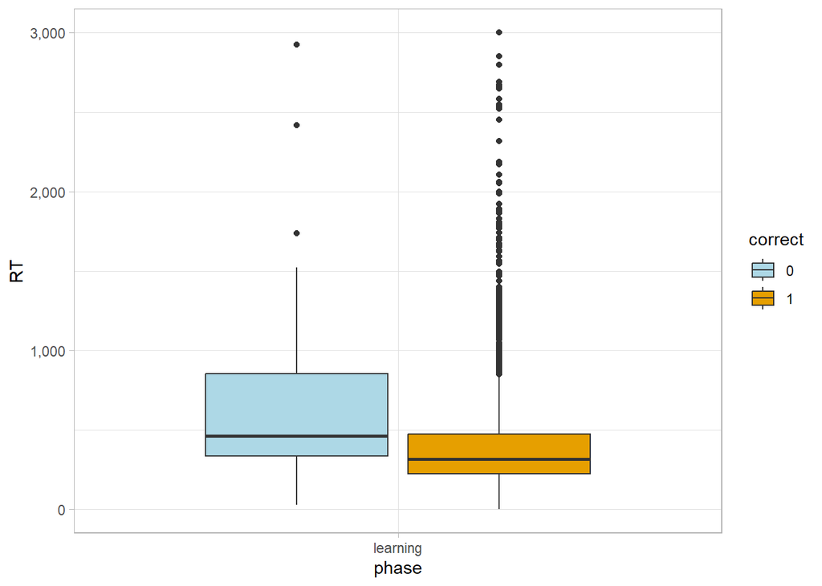

```r
learning_twochoice_RT_df <- df %>%
  mutate(correct = as.factor(correct)) %>%
  filter(component %in% c("control-learning",
                          "reward-learning",
                          "transition-learning",
                          "goal-state-learning",
                          "policy-learning"),
         state %in% c(1,2,3))

ggplot(learning_twochoice_RT_df, aes(x=phase, y=RT, fill = correct)) +
  geom_boxplot() +
  scale_y_continuous(labels = scales::comma) +
  theme_light() +
  scale_fill_manual(values=c('lightblue','#E69F00','seagreen','grey','pink'))
```

```r
learning_state1_RT_condition_phase_correct_df <- df %>%
  filter(component %in% c("control-learning",
                          "reward-learning",
                          "transition-learning",
                          "goal-state-learning"),
         state %in% c(1)) %>%
  group_by(condition, phase, correct) %>%
  summarise(mean_RT = mean(RT),
            se_RT = sd(RT, na.rm = TRUE)/sqrt(n()),
            ci_l = ci(RT, na.rm=TRUE)[2],
            ci_u = ci(RT, na.rm=TRUE)[3],
            n = n())

learning_state1_RT_condition_phase_correct_df %>%
  kable("html") %>%
  kable_styling(font_size = 16,
                latex_options = "scale_down")
```

| condition | phase | correct | mean_RT | se_RT | ci_l | ci_u | n |
| --- | --- | --- | --- | --- | --- | --- | --- |
| control | learning | 0 | 780.9500 | 145.66823 | 473.6169 | 1088.2831 | 18 |
| control | learning | 1 | 463.3532 | 21.75857 | 420.5553 | 506.1511 | 342 |
| goal-state | learning | 0 | 468.6875 | 140.36632 | 136.7739 | 800.6011 | 8 |
| goal-state | learning | 1 | 415.5648 | 16.30515 | 383.4967 | 447.6329 | 352 |
| reward | learning | 0 | 1120.6143 | 312.67934 | 355.5155 | 1885.7131 | 7 |
| reward | learning | 1 | 405.9527 | 18.78461 | 369.0085 | 442.8969 | 353 |
| transition | learning | 0 | 373.5000 | 35.11284 | 261.7553 | 485.2447 | 4 |
| transition | learning | 1 | 416.2871 | 17.29923 | 382.2652 | 450.3089 | 356 |

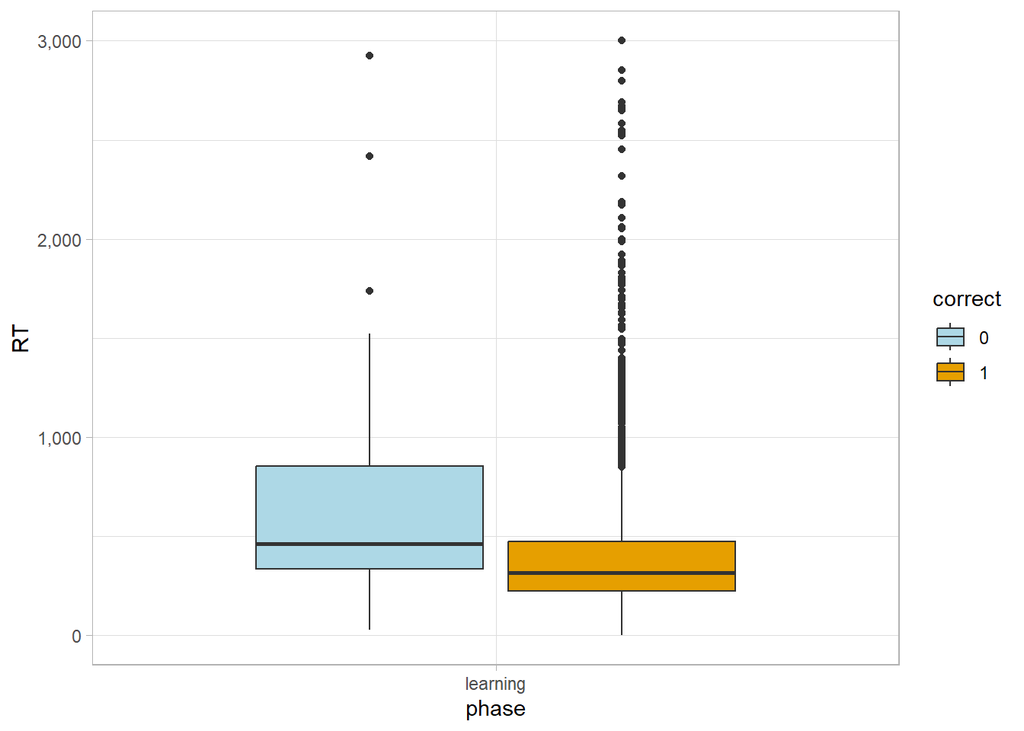

```r
learning_state1_RT_df <- df %>%
  mutate(correct = as.factor(correct)) %>%
  filter(component %in% c("control-learning",
                          "reward-learning",
                          "transition-learning",
                          "goal-state-learning",
                          "policy-learning"),
         state %in% c(1,2,3))

ggplot(learning_state1_RT_df, aes(x=phase, y=RT, fill = correct)) +
  geom_boxplot() +
  scale_y_continuous(labels = scales::comma) +
  theme_light() +
  scale_fill_manual(values=c('lightblue','#E69F00','seagreen','grey','pink'))
```

#### Test RT in 2-choice states - correct choice

```r
test_RT_condition_phase_correct_df <- df %>%
  filter(component %in% c("control-test",
                          "reward-test",
                          "transition-test",
                          "goal-state-test",
                          "policy-test")
         ) %>%
  group_by(condition, phase, correct) %>%
  summarise(mean_RT = mean(RT),
            se_RT = sd(RT, na.rm = TRUE)/sqrt(n()),
            ci_l = ci(RT, na.rm=TRUE)[2],
            ci_u = ci(RT, na.rm=TRUE)[3],
            n = n())

test_RT_condition_phase_correct_df %>%
  kable("html") %>%
  kable_styling(font_size = 16,
                latex_options = "scale_down")
```

| condition | phase | correct | mean_RT | se_RT | ci_l | ci_u | n |
| --- | --- | --- | --- | --- | --- | --- | --- |
| control | test | 0 | 712.4000 | 91.46842 | 523.1832 | 901.6168 | 24 |
| control | test | 1 | 464.1736 | 45.88003 | 373.8528 | 554.4943 | 276 |
| goal-state | test | 0 | 757.0050 | 125.46170 | 505.9567 | 1008.0533 | 60 |
| goal-state | test | 1 | 517.7742 | 51.82075 | 415.6904 | 619.8579 | 240 |
| policy | test | 0 | 668.1419 | 86.36789 | 495.4387 | 840.8452 | 62 |
| policy | test | 1 | 457.1193 | 37.55485 | 383.1354 | 531.1033 | 238 |
| reward | test | 0 | 932.2750 | 128.82990 | 673.1027 | 1191.4473 | 48 |
| reward | test | 1 | 466.1472 | 35.20160 | 396.8191 | 535.4754 | 252 |
| transition | test | 0 | 668.0306 | 92.51367 | 484.6902 | 851.3710 | 111 |
| transition | test | 1 | 420.8910 | 37.76641 | 346.3906 | 495.3914 | 189 |

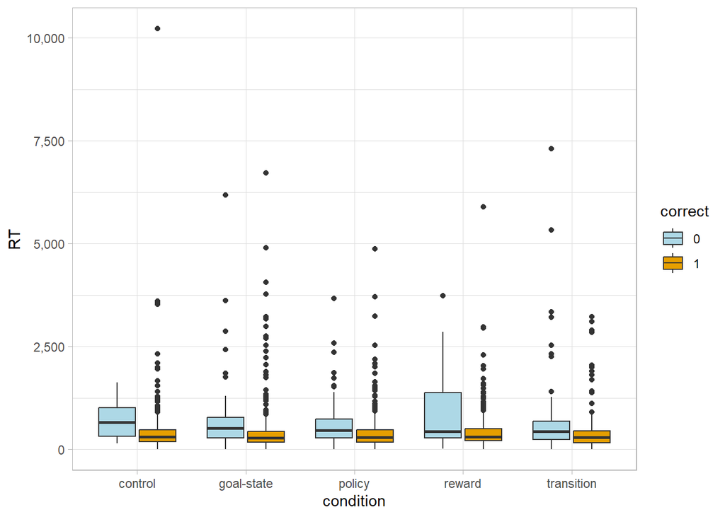

```r
test_RT_df <- df %>%
  mutate(correct = as.factor(correct)) %>%
  filter(component %in% c("control-test",
                          "reward-test",
                          "transition-test",
                          "policy-test",
                          "goal-state-test"))

ggplot(test_RT_df, aes(x=condition, y=RT, fill = correct)) +
  geom_boxplot() +
  scale_y_continuous(labels = scales::comma) +
  theme_light() +
  scale_fill_manual(values=c('lightblue','#E69F00','seagreen','grey','pink'))
```

#### Test RT state 1 - correct choice

```r
test_state1_RT_condition_phase_correct_df <- df %>%
  filter(component %in% c("control-test",
                          "reward-test",
                          "transition-test",
                          "goal-state-test",
                          "policy-test"),
         state %in% c(1)) %>%
  group_by(condition, phase, correct) %>%
  summarise(mean_RT = mean(RT),
            se_RT = sd(RT, na.rm = TRUE)/sqrt(n()),
            ci_l = ci(RT, na.rm=TRUE)[2],
            ci_u = ci(RT, na.rm=TRUE)[3],
            n = n())

test_state1_RT_condition_phase_correct_df %>%
  kable("html") %>%
  kable_styling(font_size = 16,
                latex_options = "scale_down")
```

| condition | phase | correct | mean_RT | se_RT | ci_l | ci_u | n |
| --- | --- | --- | --- | --- | --- | --- | --- |
| control | test | 0 | 898.7083 | 138.02277 | 594.9223 | 1202.4944 | 12 |
| control | test | 1 | 534.4370 | 80.77291 | 374.7141 | 694.1598 | 138 |
| goal-state | test | 0 | 630.8091 | 132.42093 | 361.0765 | 900.5417 | 33 |
| goal-state | test | 1 | 586.4350 | 68.75939 | 450.2484 | 722.6217 | 117 |
| policy | test | 0 | 839.5069 | 158.32547 | 515.1919 | 1163.8219 | 29 |
| policy | test | 1 | 562.4298 | 66.54103 | 430.6831 | 694.1764 | 121 |
| reward | test | 0 | 1186.2379 | 186.24686 | 804.7285 | 1567.7473 | 29 |
| reward | test | 1 | 558.5785 | 65.21308 | 429.4611 | 687.6959 | 121 |
| transition | test | 0 | 648.9118 | 111.39160 | 427.3973 | 870.4262 | 85 |
| transition | test | 1 | 539.9692 | 76.61984 | 386.9035 | 693.0350 | 65 |

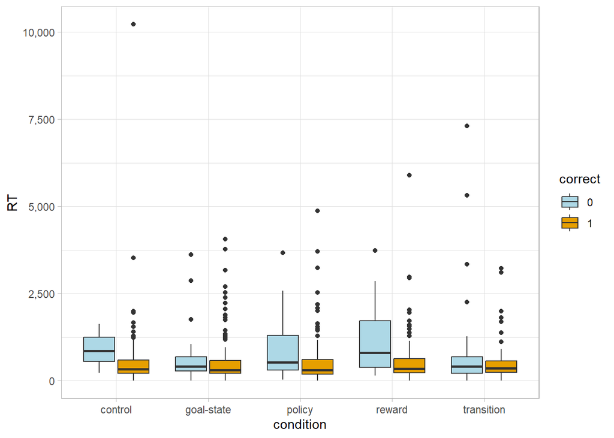

```r
test_state1_RT_df <- df %>%
  mutate(correct = as.factor(correct)) %>%
  filter(component %in% c("control-test",
                          "reward-test",
                          "transition-test",
                          "policy-test",
                          "goal-state-test"),
         state %in% c(1))

ggplot(test_state1_RT_df, aes(x=condition, y=RT, fill = correct)) +
  geom_boxplot() +
  scale_y_continuous(labels = scales::comma) +
  theme_light() +
  scale_fill_manual(values=c('lightblue','#E69F00','seagreen','grey','pink'))
```

## 1-choice states

### RT in 1-choice states per condition and phase

```r
onechoice_RT_condition_phase_df <- df %>%
  filter(component %in% c("control-learning",
                          "control-relearning",
                          "reward-learning",
                          "reward-relearning",
                          "transition-learning",
                          "transition-relearning",
                          "policy-learning",
                          "policy-relearning",
                          "goal-state-learning",
                          "goal-state-relearning"),
         state %in% c(4,5,6,7,8,9,10)) %>%
  group_by(condition, phase) %>%
  summarise(mean_RT = mean(RT),
            se_RT = sd(RT, na.rm = TRUE)/sqrt(n()),
            ci_l = ci(RT, na.rm=TRUE)[2],
            ci_u = ci(RT, na.rm=TRUE)[3])

onechoice_RT_condition_phase_df %>%
  kable("html") %>%
  kable_styling(font_size = 16,
                latex_options = "scale_down")
```

| condition | phase | mean_RT | se_RT | ci_l | ci_u |
| --- | --- | --- | --- | --- | --- |
| control | learning | 423.7543 | 5.997862 | 411.9921 | 435.5165 |
| control | relearning | 391.4679 | 8.580552 | 374.6253 | 408.3106 |
| goal-state | learning | 427.9020 | 6.373588 | 415.4030 | 440.4010 |
| goal-state | relearning | 436.3967 | 10.498611 | 415.7896 | 457.0039 |
| policy | learning | 397.5331 | 5.781127 | 386.1960 | 408.8703 |
| policy | relearning | 428.5234 | 9.489494 | 409.8965 | 447.1503 |
| reward | learning | 398.0623 | 5.829128 | 386.6310 | 409.4936 |
| reward | relearning | 423.0160 | 10.489911 | 402.4254 | 443.6066 |
| transition | learning | 397.2145 | 5.560317 | 386.3104 | 408.1187 |
| transition | relearning | 426.1380 | 9.712253 | 407.0739 | 445.2021 |

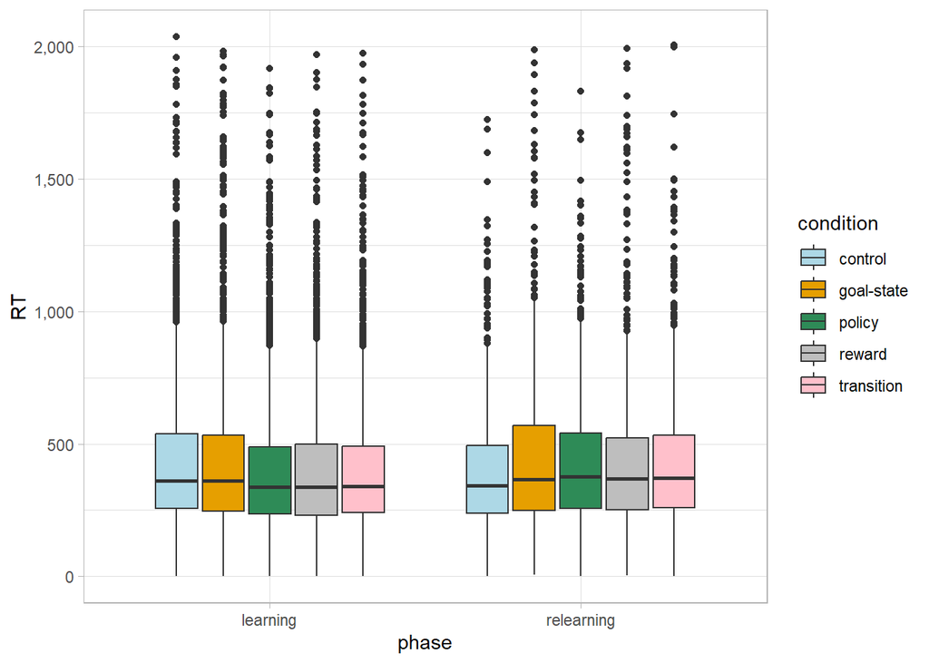

```r
onechoice_RT_df <- df %>%
  filter(component %in% c("control-learning",
                          "control-relearning",
                          "reward-learning",
                          "reward-relearning",
                          "transition-learning",
                          "transition-relearning",
                          "policy-learning",
                          "policy-relearning",
                          "goal-state-learning",
                          "goal-state-relearning"),
         state %in% c(4,5,6,7,8,9,10))

ggplot(onechoice_RT_df, aes(x=phase, y=RT, fill = condition)) +
  geom_boxplot() +
  scale_y_continuous(labels = scales::comma) +
  theme_light() +
  scale_fill_manual(values=c('lightblue','#E69F00','seagreen','grey','pink'))
```